# Statistical Inference

**References**

- [Coursera Data Science Statistical Inference](https://github.com/DataScienceSpecialization/courses/tree/master/06_StatisticalInference)
- [Xing Su Notes](http://sux13.github.io/DataScienceSpCourseNotes/6_STATINFERENCE/Statistical_Inference_Course_Notes.html) (These notes are provided by Xing Su with some minor modications. Special thanks go to him)

# 1 Overview

- **Statistical Inference** = generating conclusions about a population from a noisy sample
- Goal = extend beyond data to population
- Statistical Inference = only formal system of inference we have
- many different modes, but **two** broad flavors of inference (inferential paradigms): *Bayesian* vs *Frequencist*
  - **Frequencist** = uses long run proportion of times an event occurs independent identically distributed repetitions
    - frequentist is what this class is focused on
    - believes if an experiment is repeated many many times, the resultant percentage of success/something happening defines that population parameter
  - **Bayesian** = probability estimate for a hypothesis is updated as additional evidence is acquired
- **statistic** = number computed from a sample of data
  - statistics are used to infer information about a population
- **random variable** = outcome from an experiment
  - deterministic processes (variance/means) produce additional random variables when applied to random variables, and they have their own distributions

# 2 Probability

- **Intro**: Probability assigns a number between 0 and 1 to events to give a sense of the “chance” of the event. Probability has become our default model for apparently random phenomena. Our eventual goal is to use probability models, our formal mechanism for connecting our data to a population.
- **Probability** = the study of quantifying the likelihood of particular events occurring
- Given a random experiment (say rolling a die), a **probability measure** is a population quantity that summarizes the randomness
  - not in the data at hand, but a conceptual quantity that exist in the population that we want to estimate

## 2.1 General Probability Rules

- discovered by Russian mathematician Kolmogorov, also known as “Probability Calculus”
- probability = function of any set of outcomes and assigns it a number between 0 and 1
  - $0 \le P(E) \le 1$, where $E$ = event
- probability that nothing occurs = 0 (impossible, have to roll dice to create outcome), that something occurs is 1 (certain)
- probability of outcome or event $E$, $P(E)$ = ratio of ways that $E$ could occur to number of all possible outcomes or events
- probability of something = 1 - probability of the opposite occurring
- probability of the **union** of any two sets of outcomes that have nothing in common (mutually exclusive) = sum of respective probabilities

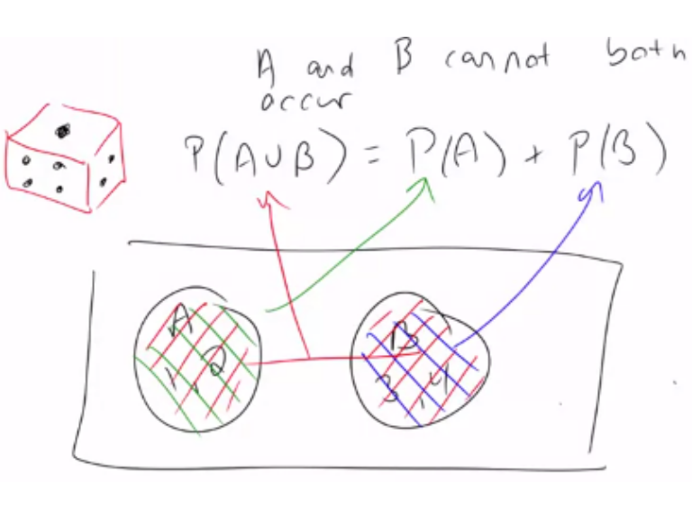

- if $A$ implies occurrence of $B$, then $P(A)$ occurring $< P(B)$ occurring

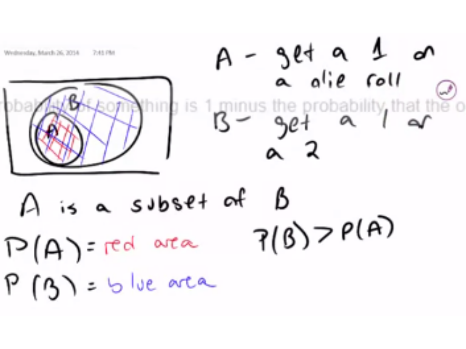

- for any two events, probability of at least one occurs = the sum of their probabilities - their intersection (in other words, probabilities can not be added simply if they have non-trivial intersection)

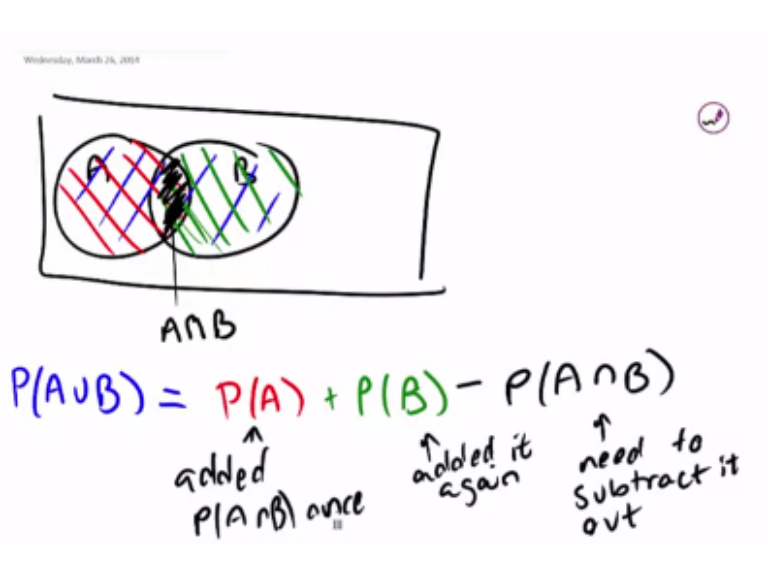

- for independent events $A$ and $B$, $P(A \:\cap\: B) = P(A) \times P(B)$
- for outcomes that can occur with different combination of events and these combinations are mutually exclusive, the $P(E_{total}) = \sum P(E_{part})$

## 2.2 Conditional Probability

- **Intro**: Conditional probability is a very intuitive idea, “What is the probability given partial information about what has occurred?”. The probability of getting hit by lightning is small. However, it’s much larger for people playing outside in open fields during a lightning storm! In these lectures we go over the formal rules of conditional probability.
- Let B = an event so that $P(B) > 0$
- **conditional probability** of an event A, given B is defined as the probability that BOTH A and B occurring divided by the probability of B occurring
  $$P(A\:|\:B) = \frac{P(A \:\cap\: B)}{P(B)}$$
- if A and B are *independent*, then
  $$P(A\:|\:B) = \frac{P(A)P(B)}{P(B)} = P(A)$$
- *Example*
  - for die roll, $A = \{1\}$, $B = \{1, 3, 5\}$, then
    $$P(1~|~Odd) = P(A\:|\:B) = \frac{P(A \cap B)}{P(B)} = \frac{P(A)}{P(B)} = \frac{1/6}{3/6} = \frac{1}{3}$$

## 2.3 Baye’s Rule

- Given $P(A \:\cap\: B) = P(A\:|B)P(B)$ and $P(A) = P(A\:|B)P(B) + P(A\:|B^c)P(B^c)$, we can define
  $$P(B\:|\:A) = \frac{P(B \:\cap\: A)}{P(A)} = \frac{P(A\:|\:B)P(B)}{P(A\:|\:B)P(B)+P(A\:|\:B^c)P(B^c)}$$
  where $B^c$ = complement probability of event $B$, $P(B^c) = 1 - P(B)$

# 3 Random Variables

- **random variable** = numeric outcome of experiment
- **discrete** (what you can count/categories) = assign probabilities to every number/value the variable can take
  - coin flip, rolling a die, web traffic in a day
- **continuous** (any number within a continuum) = assign probabilities to the range the variable can take
  - BMI index, intelligence quotients
  - **Note**: limitations of precision in taking the measurements may imply that the values are discrete, but we in fact consider them continuous
- `rbinom()`, `rnorm()`, `rgamma()`, `rpois()`, `runif()` = functions to generate random variables from the binomial, normal, Gamma, Poisson, and uniform distributions
- density and mass functions (population quantities, not what occurs in data) for random variables = best starting point to model/think about probabilities for numeric outcome of experiments (variables)
  - use data to estimate properties of population $\rightarrow$ linking sample to population

## 3.1 Probability Mass Function (PMF)

- evaluates the probability that the **discrete random variable** takes on a specific value
  - measures the chance of a particular outcome happening
  - always $\ge$ 0 for every possible outcome
  - $\sum$ possible values that the variable can take = 1
- *Bernoulli distribution Example*
  - X = 0 $\rightarrow$ tails, X = 1 $\rightarrow$ heads
    - X here represents potential outcome
  - $P(X = x) = (\frac{1}{2})^x(\frac{1}{2})^{1-x}$ for $X = 0, 1$
    - $x$ here represents a value we can plug into the PMF
    - general form $\rightarrow$ $p(x) = (\theta)^x(1-\theta)^{1-x}$ for $x=0,1$
- `dbinom(k, n, p)` = return the probability of getting `k` successes out of `n` trials, given probability of success is `p`

## 3.2 Probability Density Function (PDF)

- evaluates the probability that the **continuous random variable** takes on a specific value
  - always $\ge$ 0 everywhere
  - total area under curve must = 1
- **areas under PDFs** correspond to the probabilities for that random variable taking on that range of values (PMF)

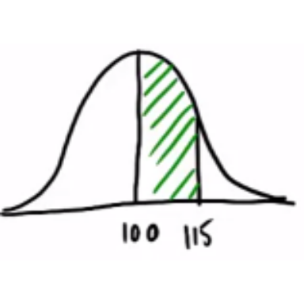

- but the probability of the variable taking a specific value = 0 (area of a line is 0)

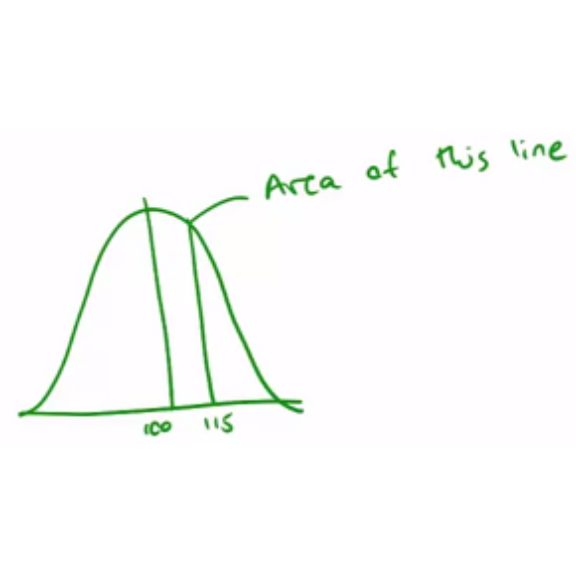

- **Note**: the above is true because it is modeling random variables as if they have infinite precision, when in reality they do not
- `dnorm()`, `dgamma()`, `dpois()`, `dunif()` = return probability of a certain value from the normal, Gamma, Poisson, and uniform distributions

## 3.3 Cumulative Distribution Function (CDF)

- CDF of a random variable $X$ = probability that the random variable is $\le$ value $x$
  - $F(x) = P(X \le x)$ = applies when $X$ is discrete/continuous
- PDF = derivative of CDF
  - integrate PDF $\rightarrow$ CDF
    - `integrate(function, lower=0, upper=1)` $\rightarrow$ can be used to evaluate integrals for a specified range
- `pbinom()`, `pnorm()`, `pgamma()`, `ppois()`, `punif()` = returns the cumulative probabilities from 0 up to a specified value from the binomial, normal, Gamma, Poisson, and uniform distributions

## 3.4 Survival Function

- survival function of a random variable $X$ = probability the random variable $> x$, complement of CDF
  - $S(x) = P(X > x) = 1 - F(x)$, where $F(x) =$ CDF

## 3.5 Quantile

- the $\alpha^{th}$ quantile of a distribution with distribution function $F$ is the point $x_{\alpha}$ so that
  $$F(x_{\alpha}) = \alpha$$
- percentile = quantile with $\alpha$ expressed as a percent
- median = 50<sup>th</sup> percentile
  - $\alpha$% of the possible outcomes lie below it

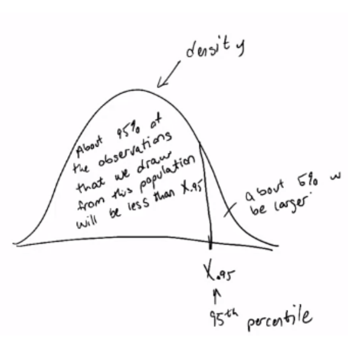

- `qbeta(quantileInDecimals, 2, 1)` = returns quantiles for beta distribution
  - works for `qnorm()`, `qbinom()`, `qgamma()`, `qpois()`, etc.
- median estimated in this fashion is a **population median**, a **population quantity**
  - probability model connects data to population using assumptions
  - population median = *estimand*, sample median = *estimator*

## 3.6 Independence

- two events $A$ and $B$ are *independent* if the following is true
  $$P(A\:\cap\:B) = P(A)P(B)$$
- Equivalently if $P(A\:|\:B) = P(A)$ where $P(B)>0$
- two random variables $X$ and $Y$ are *independent*, if for any two sets, **A** and **B**, the following is true
  $$P([X \in A]\cap[Y \in B]) = P(X \in A)P(Y \in B)$$
- **independence** = statistically unrelated from one another
- if $A$ is *independent* of $B$, then the following are true
  - $A^c$ is independent of $B$
  - $A$ is independent of $B^c$
  - $A^c$ is independent of $B^c$

## 3.7 IID Random Variables

- random variables are said to be **IID** if they are *independent and identically distributed*
  - **independent** = statistically unrelated from each other
  - **identically distributed** = all having been drawn from the same population distribution
- IID random variables = default model for random samples = default starting point of inference

# 4 Diagnostic Test

- Let $+$ and $-$ be the results, positive and negative respectively, of a diagnostic test
- Let $D$ = subject of the test has the disease, $D^c$ = subject does not
- **sensitivity** = $P(+\:|\:D)$ = probability that the test is positive given that the subject has the disease (the higher the better)
- **specificity** = $P(-\:|\:D^c)$ = probability that the test is negative given that the subject does not have the disease (the higher the better)
- **positive predictive value** = $P(D\:|\:+)$ = probability that that subject has the disease given that the test is positive
- **negative predictive value** = $P(D^c\:|\:-)$ = probability that the subject does not have the disease given the test is negative
- **prevalence of disease** = $P(D)$ = marginal probability of disease

## 4.1 Example

- specificity of 98.5%, sensitivity = 99.7%, prevalence of disease = .1%; using **Baye’s Rule** we have
  $$\begin{aligned}
  P(D ~|~ +) & = \frac{P(+~|~D)P(D)}{P(+~|~D)P(D) + P(+~|~D^c)P(D^c)}\\
  & = \frac{P(+~|~D)P(D)}{P(+~|~D)P(D) + \{1-P(-~|~D^c)\}\{1 - P(D)\}} \\
  & = \frac{.997\times .001}{.997 \times .001 + .015 \times .999}\\
  & = .062
  \end{aligned}$$
- low **positive predictive value** $\rightarrow$ due to low prevalence of disease and somewhat modest specificity
  - suppose it was known that the subject uses drugs and has regular intercourse with an HIV infect partner (his probability of being + is higher than suspected)
  - evidence implied by a positive test result

## 4.2 Likelihood Ratios

- **diagnostic likelihood ratio** of a **positive** test result is defined as
  $$DLR_+ = \frac{sensitivity}{1-specificity} = \frac{P(+\:|\:D)}{P(+\:|\:D^c)}$$
- **diagnostic likelihood ratio** of a **negative** test result is defined as
  $$DLR_- = \frac{1 - sensitivity}{specificity} = \frac{P(-\:|\:D)}{P(-\:|\:D^c)}$$
- from Baye’s Rules, we can derive the *positive predictive value* and *false positive value*
  $$P(D\:|\:+) = \frac{P(+\:|\:D)P(D)}{P(+\:|\:D)P(D)+P(+\:|\:D^c)P(D^c)} ~~~~~~ \mbox{(1)}$$
  $$P(D^c\:|\:+) = \frac{P(+\:|\:D^c)P(D^c)}{P(+\:|\:D)P(D)+P(+\:|\:D^c)P(D^c)} ~~~~~~ \mbox{(2)}$$
- if we divide equation $(1)$ over $(2)$, the quantities over have the same denominator so we get the following
  $$\frac{P(D\:|\:+)}{P(D^c\:|\:+)} = \frac{P(+\:|\:D)}{P(+\:|\:D^c)} \times \frac{P(D)}{P(D^c)}$$
  which can also be written as
  $$\mbox{post-test odds of D} = DLR_+ \times \mbox{pre-test odds of D}$$
  - **odds** = $p/(1-p)$
  - $\frac{P(D)}{P(D^c)}$ = **pre-test odds**, or odds of disease in absence of test
  - $\frac{P(D\:|\:+)}{P(+\:|\:D^c)}$ = **post-test odds**, or odds of disease given a positive test result
  - $DLR_+$ = factor by which the odds in the presence of a positive test can be multiplied to obtain the post-test odds
  - $DLR_-$ = relates the **decrease** in odds of disease after a negative result
- following the previous example, for sensitivity of 0.997 and specificity of 0.985, so the diagnostic likelihood ratios are as follows
  $$DLR_+ = .997/(1-.985) = 66 ~~~~~~ DLR_- =(1-.997)/.985 = 0.003$$
  - this indicates that the result of the positive test is that the odds of disease is 66 times the pretest odds
  - Or in other words, the hypothesis of disease is 66 times more supported by the data than the hypothesis of no disease.
  - Suppose that a subject has a negative test result
    - $DLR_- = (1-.997)/.985 = 0.003$
    - Therefore, the post-test odds of disease is now 0.3% of the pre-test odds given the negative test.
    - Or, the hypothesis of disease is supported 0.003 times that of the hypothesis of no disease given the negative test result.

# 5 Expected Values/Mean

- **Intro**: The empirical average is a very intuitive idea; it’s the middle of our data in a sense. But, what is it estimating? We can formally define the middle of a population distribution. This is the expected value. Expected values are very useful for characterizing populations and usually represent the first thing that we’re interested in estimating.
- useful for characterizing a distribution (properties of distributions)
- **mean** = characterization of the center of the distribution = *expected value*
- expected value operation = *linear* $\rightarrow$ $E(aX +bY) = aE(X) + bE(Y)$
- **variance/standard deviation** = characterization of how spread out the distribution is
- *sample* expected values for sample mean and variance will estimate the *population* counterparts
- **population mean**
  - expected value/mean of a random variable = center of its distribution (center of mass)
  - *discrete variables*
    - for $X$ with PMF $p(x)$, the population mean is defined as
      $$E[X] = \sum_{x} xp(x)$$
      where the sum is taken over *all* possible values of $x$
    - $E[X]$ = center of mass of a collection of location and weights ${x,~p(x)}$
    - *coin flip example*: $E[X] = 0 \times (1-p) + 1 \times p = p$
  - *continuous variable*
    - for $X$ with PDF $f(x)$, the expected value = the center of mass of the density
    - instead of summing over discrete values, the expectation *integrates* over a continuous function
      - PDF = $f(x)$
      - $\int xf(x)$ = area under the PDF curve = mean/expected value of $X$
- **sample mean**
  - sample mean estimates the population mean
    - sample mean = center of mass of observed data = empirical mean
      $$\bar X = \sum_{x}^n x_i p(x_i)$$
      where $p(x_i) = 1/n$

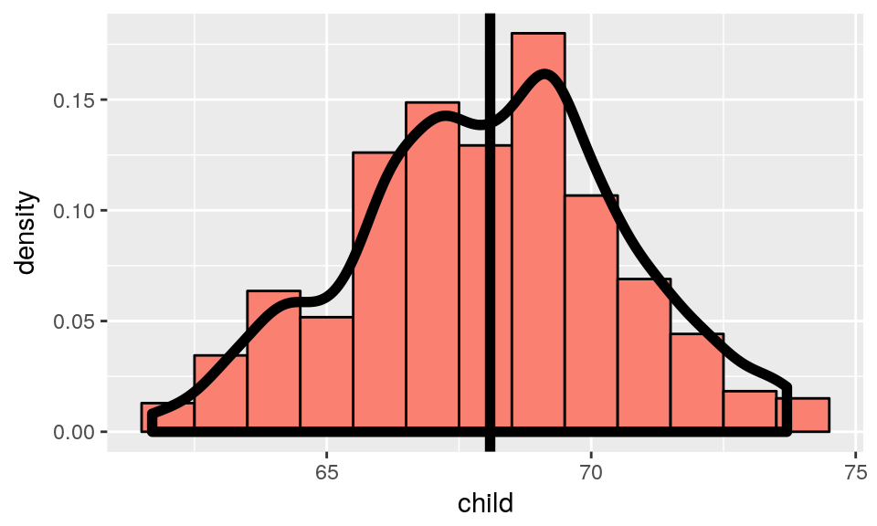

```r
# load relevant packages
library(UsingR); data(galton); library(ggplot2)
# plot galton data
g <- ggplot(galton, aes(x = child))
# add histogram for children data
g <- g + geom_histogram(fill = "salmon", binwidth=1, aes(y=..density..), colour="black")
# add density smooth
g <- g + geom_density(size = 2)
# add vertical line
g <- g + geom_vline(xintercept = mean(galton$child), size = 2)
# print graph
g
```

- **average of random variables** is itself a new random variable where its distribution has an expected value that is the **same** as the original distribution (centers are the same)
  - the mean of the averages = average of the original data $\rightarrow$ estimates average of the population
  - if $E[sample~mean]$ = population mean, then estimator for the sample mean is **unbiased** (more formally: an estimator $e$ of some parameter $v$ is unbiased if its expected value equals $v$, i.e., $E(e)=v$)
    - [**derivation**] let $X_1$, $X_2$, $X_3$, … $X_n$ be a collection of $n$ samples from the population with mean $\mu$
    - mean of this sample
      $$\bar X = \frac{X_1 + X_2 + X_3 + . + X_n}{n}$$
    - since $E(aX) = aE(X)$, the expected value of the mean is can be written as
      $$E\left[\frac{X_1 + X_2 + X_3 + ... + X_n}{n}\right] = \frac{1}{n} \times [E(X_1) + E(X_2) + E(X_3) + ... + E(X_n)]$$
    - since each of the $E(X_i)$ is drawn from the population with mean $\mu$, the expected value of each sample should be
      $$E(X_i) = \mu$$
    - therefore
      $$\begin{aligned}
      E\left[\frac{X_1 + X_2 + X_3 + ... + X_n}{n}\right] & = \frac{1}{n} \times [E(X_1) + E(X_2) + E(X_3) + ... + E(X_n)]\\
      & = \frac{1}{n} \times [\mu + \mu + \mu + ... + \mu]\\
      & = \frac{1}{n} \times n \times \mu\\
      & = \mu\\
      \end{aligned}$$
- **Illustrative Example**: Below graph shows how a sample mean and the mean of averages spike together. The two shaded distributions come from the same data. The blue portion represents the density function of randomly generated standard normal data, 10000 samples. The pink portion represents the density function of 10000 averages, each of 10 random normals. (The original data was stored in a 10000 x 10 array and the average of each row was taken to generate the pink data.)  
  **Note**: the more data that goes into the sample mean, the more concentrated its density/mass functions are around the population mean

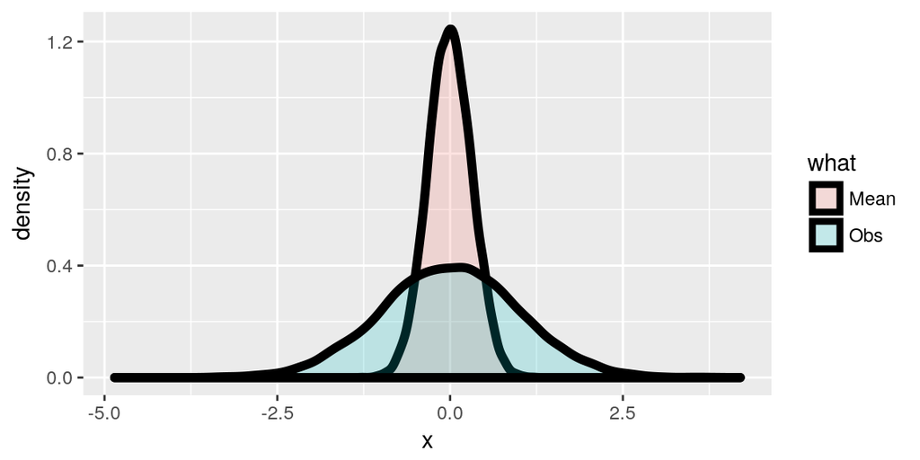

```r
library(ggplot2)
nosim <- 10000; n <- 10
dat <- data.frame(
  x = c(rnorm(nosim), apply(matrix(rnorm(nosim * n), nosim), 1, mean)),
  what = factor(rep(c("Obs", "Mean"), c(nosim, nosim)))
)
np <- ggplot(dat, aes(x = x, fill = what)) + geom_density(size = 2, alpha = .2);
print(np)
```

- Another Example: Rolling a single die 1000 times yields the first figure. Each of the 6 possible outcomes appears with about the same frequency. The second figure is the histogram of outcomes of the average of rolling two dice. Similarly, the third figure is the histogram of averages of rolling three dice, and the fourth four dice. As we showed previously, the center or mean of the original distribution is 3.5 and that’s exactly where all the panels are centered.

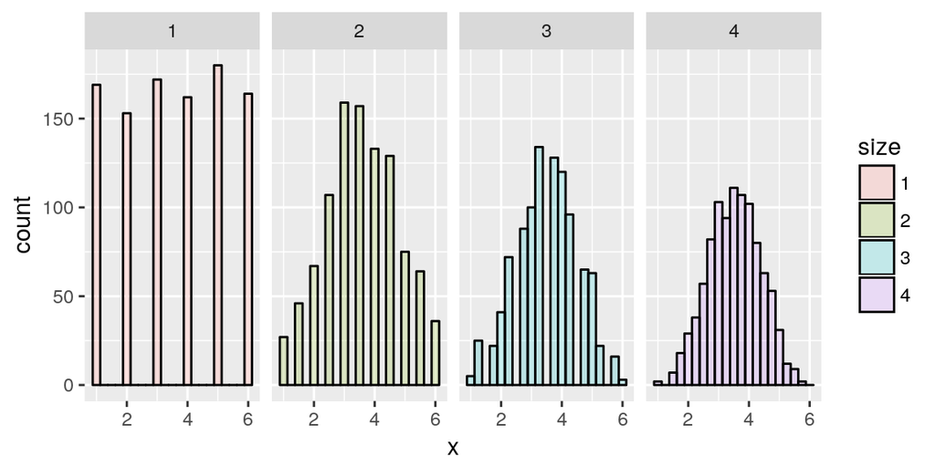

```r
# Simulating dice rolls
# (1) rolling a dice once, repeated 1000 times
# (2) rolling a dice twice and take the average of the two outcomes, repeat 1000 times
# (3) rolling three times and take the average, repeated 1000 times
# (4) roll four times and take average, repeated 1000 times
# mean of the averages in (2), (3) or (4) will be the same as in (1) => unbiased estimate of the population mean
nosim <- 1000
dat <- data.frame(
    x = c(sample(1 : 6, nosim, replace = TRUE),
        apply(matrix(sample(1 : 6, nosim * 2, replace = TRUE), nosim), 1, mean),
        apply(matrix(sample(1 : 6, nosim * 3, replace = TRUE), nosim), 1, mean),
        apply(matrix(sample(1 : 6, nosim * 4, replace = TRUE), nosim), 1, mean)),
    size = factor(rep(1 : 4, rep(nosim, 4))))
# plot histograms of means by sample size
g <- ggplot(dat, aes(x = x, fill = size)) + geom_histogram(alpha = .20, binwidth=.25, colour = "black")
g + facet_grid(. ~ size)
```

# 6 Variance

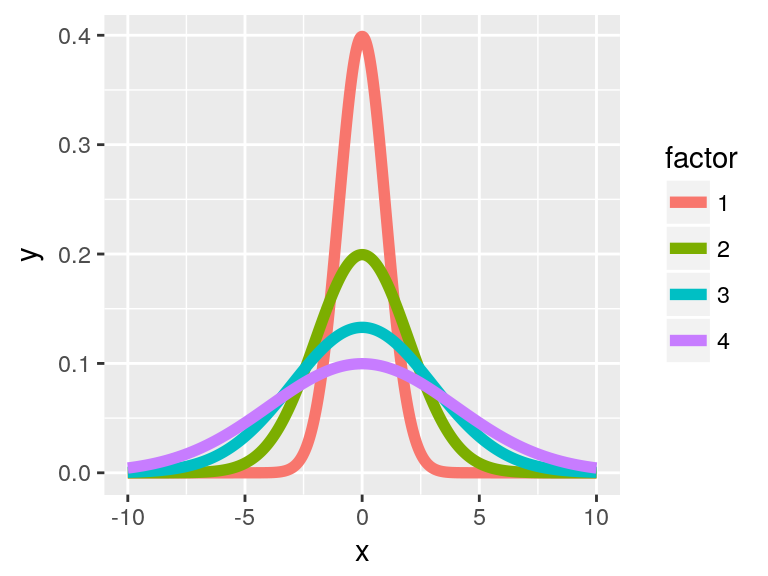

```r
# generate x value ranges
xvals <- seq(-10, 10, by = .01)
# generate data from normal distribution for sd of 1 to 4
dat <- data.frame(
    y = c(dnorm(xvals, mean = 0, sd = 1),
        dnorm(xvals, mean = 0, sd = 2),
        dnorm(xvals, mean = 0, sd = 3),
        dnorm(xvals, mean = 0, sd = 4)),
    x = rep(xvals, 4),
    factor = factor(rep(1 : 4, rep(length(xvals), 4)))
)
# plot 4 lines for the different standard deviations
ggplot(dat, aes(x = x, y = y, color = factor)) + geom_line(size = 2)
```

## 6.1 Sample Variance

- the **sample variance** is defined as
  $$S^2 = \frac{\sum_{i=1} (X_i - \bar X)^2}{n-1}$$
- It is also a random variable
  - It has an associated population distribution
  - Its expected value is the population variance

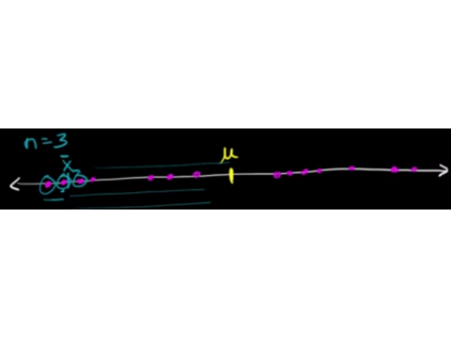

- on the above line representing the population (in magenta), any subset of data (3 of 14 selected, marked in blue) will most likely have a variance that is *lower than* the population variance
- dividing by $n - 1$ will make the variance estimator *larger* to adjust for this fact $\rightarrow$ leads to more accurate estimation $\rightarrow$ $S^2$ = so called *unbiased estimate of population variance*
  - $S^2$ is a random variable, and therefore has an associated population distribution
    - $E[S^2]$ = population variance, where $S$ = sample standard deviation
    - as we see from the simulation results below, with more data, the distribution for $S^2$ gets more concentrated around population variance

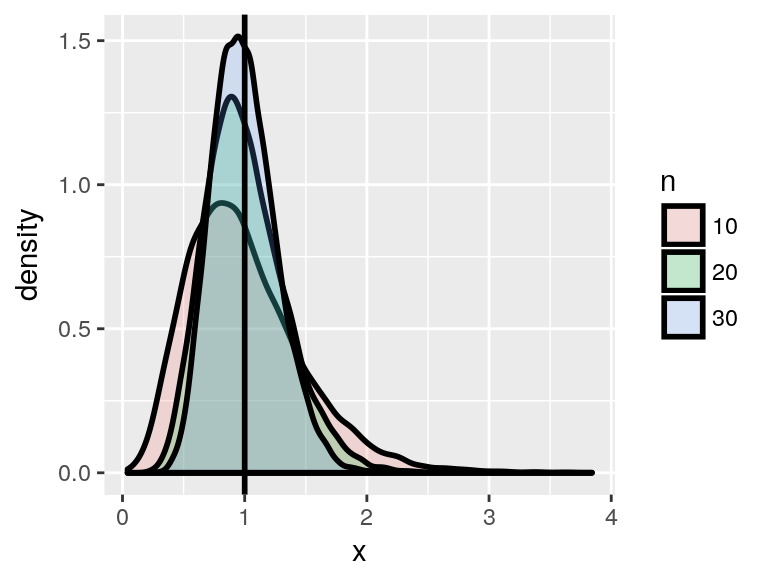

```r
# specify number of simulations
nosim <- 10000;
# simulate data from a population with variance 1
dat <- data.frame(
    x = c(apply(matrix(rnorm(nosim * 10), nosim), 1, var),
          apply(matrix(rnorm(nosim * 20), nosim), 1, var),
          apply(matrix(rnorm(nosim * 30), nosim), 1, var)),
    n = factor(rep(c("10", "20", "30"), c(nosim, nosim, nosim))) )
# plot density function for different sample size data
ggplot(dat, aes(x = x, fill = n)) + geom_density(size = 1, alpha = .2) +
    geom_vline(xintercept = 1, size = 1)
```

- Recall that the average of random samples from a population is itself a random variable with a distribution centered around the population mean. Specifically, $E(\bar X) = \mu$, where $\bar X$ represents a sample mean and $\mu$ is the population mean. We can show that, if the population is infinite, the variance of the sample mean is the population variance divided by the sample size. Assume $X_1,...,X_n$ are iid

## 6.2 Standard error of the mean

- **Note**: for any variable, properties of the population = **parameter**, estimates of properties for samples = **statistic**
  - below is a summary for the mean and variance for population and sample

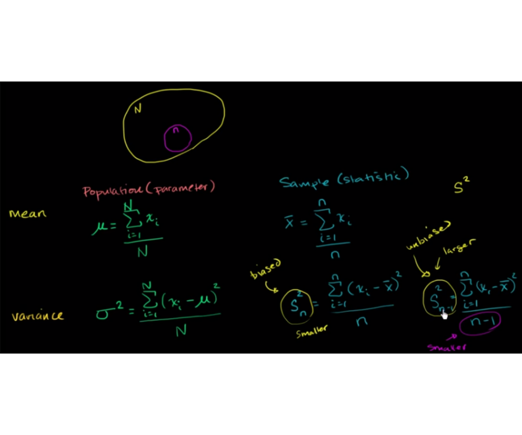

- **distribution for mean of random samples**
  - expected value of the **mean** of distribution of means = expected value of the sample mean = population mean
    - $E[\bar X]=\mu$
  - expected value of the variance of distribution of means = variance of the sample mean = population variance divided by $n$
    - $Var(\bar X) = \sigma^2/n$
    - as $n$ becomes larger, the mean of random sample $\rightarrow$ more concentrated around the population mean $\rightarrow$ variance approaches 0
      - this again confirms that sample mean estimates population mean
  - **Note**: normally we only have 1 sample mean (from collected sample) and can estimate the variance $\sigma^2$ $\rightarrow$ so we know a lot about the **distribution of the means** from the data observed
- **standard error (SE)**
  - we call the standard deviation of a statistic a standard error
  - the standard error of the mean is defined as
    $$SE_{mean} = \sigma/\sqrt{n}$$
  - this quantity is effectively the standard deviation of the distribution of our statistic (i.e. mean)
  - represents variability of means

## 6.3 Entire Estimator-Estimation Relationship

- Start with a sample
- $S^2$ = sample variance
  - estimates how variable the population is
  - estimates population variance $\sigma^2$
  - $S^2$ = a random variable and has its own distribution centered around $\sigma^2$
    - more concentrated around $\sigma^2$ as $n$ increases
- $\bar X$ = sample mean
  - estimates population mean $\mu$
  - $\bar X$ = a random variable and has its own distribution centered around $\mu$
    - more concentrated around $\mu$ as $n$ increases
    - variance of distribution of $\bar X = \sigma^2/n$
    - estimate of variance = $S^2/n$
    - estimate of standard error = $S/\sqrt{n}$ $\rightarrow$ “sample standard error of the mean”
      - The sample standard deviation $S$ tells us how variable the population is, and
      - the standard error $S/\sqrt{n}$ tells us how much averages of random samples of size $n$ from the population vary

## 6.4 Example - Standard Normal

- variance = 1
- means of $n$ standard normals (sample) have standard deviation = $1/\sqrt{n}$

```r
# specify number of simulations with 10 as number of observations per sample
nosim <- 1000; n <-10
# estimated standard deviation of mean
sd(apply(matrix(rnorm(nosim * n), nosim), 1, mean))
```

```
## [1] 0.3159142
```

```r
# actual standard deviation of mean of standard normals
1 / sqrt(n)
```

```
## [1] 0.3162278
```

- `rnorm()` = generate samples from the standard normal
- `matrix()` = puts all samples into a nosim by $n$ matrix, so that each row represents a simulation with `nosim` observations
- `apply()` = calculates the mean of the $n$ samples
- `sd()` = returns standard deviation

## 6.5 Example - Standard Uniform

- standard uniform $\rightarrow$ triangle straight line distribution $\rightarrow$ mean = 1/2 and variance = 1/12
- means of random samples of $n$ uniforms have have standard deviation of $1/\sqrt{12 \times n}$

```r
# estimated standard deviation of the sample means
sd(apply(matrix(runif(nosim * n), nosim), 1, mean))
```

```
## [1] 0.0891203
```

```r
# actual standard deviation of the means
1/sqrt(12*n)
```

```
## [1] 0.09128709
```

## 6.6 Example - Poisson

- $Poisson(x^2)$ have variance of $x^2$
- means of random samples of $n~ Poisson(4)$ have standard deviation of $2/\sqrt{n}$

```r
# estimated standard deviation of the sample means
sd(apply(matrix(rpois(nosim * n, lambda=4), nosim), 1, mean))
```

```
## [1] 0.6525976
```

```r
# actual standard deviation of the means
2/sqrt(n)
```

```
## [1] 0.6324555
```

## 6.7 Example - Bernoulli

- for $p = 0.5$, the Bernoulli distribution has variance $Var(X) = p(1-p) = 0.25$
- means of random samples of $n$ coin flips have standard deviations of $1 / (2 \sqrt{n})$

```r
# estimated standard deviation of the sample means
sd(apply(matrix(sample(0 : 1, nosim * n, replace = TRUE), nosim), 1, mean))
```

```
## [1] 0.1562677
```

```r
# actual standard deviation of the means
1/(2*sqrt(n))
```

```
## [1] 0.1581139
```

## 6.8 Example - Father/Son

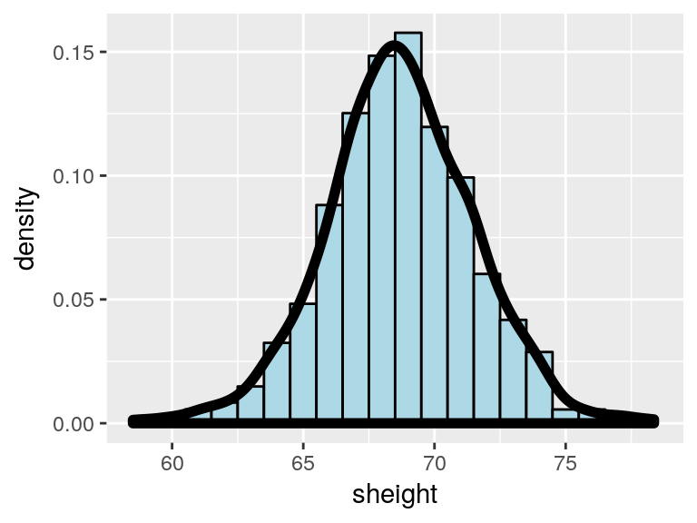

```r
# load data
library(UsingR); data(father.son);
# define son height as the x variable
x <- father.son$sheight
# n is the length
n<-length(x)
# plot histogram for son's heights
g <- ggplot(data = father.son, aes(x = sheight))
g <- g + geom_histogram(aes(y = ..density..), fill = "lightblue", binwidth=1, colour = "black")
g <- g + geom_density(size = 2, colour = "black")
g
```

```r
# we calculate the parameters for variance of distribution and sample mean,
round(c(sampleVar = var(x),
    sampleMeanVar = var(x) / n,
    # as well as standard deviation of distribution and sample mean
    sampleSd = sd(x),
    sampleMeanSd = sd(x) / sqrt(n)),2)
```

```
##     sampleVar sampleMeanVar      sampleSd  sampleMeanSd
##          7.92          0.01          2.81          0.09
```

# 7 Binomial Distribution

- **binomial random variable** = sum of $n$ Bernoulli variables
  $$X = \sum_{i=1}^n X_i$$
  where $X_1,\ldots,X_n =$ iid $Bernoulli(p)$
  - PMF is defined as
    $$P(X=x) = {n \choose x}p^x(1-p)^{n-x}$$
    where ${n \choose x}$ = number of ways selecting $x$ items out of $n$ options *without replacement* or *regard to order* and for $x=0,\ldots,n$
  - **combination** or “$n$ choose $x$” is defined as
    $${n \choose x} = \frac{n!}{x!(n-x)!}$$
  - the base cases are
    $${n \choose n} = {n \choose 0} = 1$$
- **Bernoulli distribution** = binary outcome
  - only possible outcomes
    - 1 = “success” with probability of $p$
    - 0 = “failure” with probability of $1 - p$
  - PMF is defined as
    $$P(X=x) = p^x(1 - p)^{1-x}$$
  - mean = $p$
  - variance = $p(1 - p)$

## 7.1 Example

- friend is 1 of 8 children, 7 of which are girls; if each gender has an independent 50% probability for each birth, what’s the probability of getting 7 or more girls out of 8 births?
  $${8 \choose 7}.5^7(1-.5)^{1} + {8 \choose 8}.5^8(1-.5)^{0} \approx 0.04$$

```r
# calculate probability using PMF
choose(8, 7) * .5 ^ 8 + choose(8, 8) * .5 ^ 8
```

```
## [1] 0.03515625
```

```r
# calculate probability using CMF from distribution
pbinom(6, size = 8, prob = .5, lower.tail = FALSE)
```

```
## [1] 0.03515625
```

- `choose(8, 7)` = R function to calculate n choose x
- `pbinom(6, size=8, prob =0.5, lower.tail=TRUE)` = probability of 6 or less successes out of 8 samples with probability of 0.5 (CMF)
  - `lower.tail=FALSE` = returns the complement, in this case it’s the probability of greater than 6 successes out of 8 samples with probability of 0.5

# 8 Normal Distribution

- normal/Gaussian distribution for random variable $X$
  - notation = $X \sim N(\mu, \sigma^2)$
  - mean = $E[X] = \mu$
  - variance = $Var(X) = \sigma^2$
  - pdf is defined as
    $$f(x)=(2\pi\sigma^2)^{-1/2}e^{-(x-\mu)^2/2\sigma^2}$$
- $X \sim N(0, 1)$ = **standard normal distribution** (standard normal random variables often denoted using $Z_1, Z_2, \ldots$)
  - **Note**: see below graph for reference for the following observations
  - ~68% of data/normal density $\rightarrow$ between $\pm$ 1 std from $\mu$ (two-sided)
  - ~95% of data/normal density $\rightarrow$ between $\pm$ 2 std from $\mu$ (two-sided)
  - ~99% of data/normal density $\rightarrow$ between $\pm$ 3 std from $\mu$ (two-sided)
  - $\pm$ 1.28 std from $\mu$ (one-sided) $\rightarrow$ 10$^{th}$ (-) and 90$^{th}$ (+) percentiles
  - $\pm$ 1.645 std from $\mu$ (one-sided) $\rightarrow$ 5$^{th}$ (-) and 95$^{th}$ (+) percentiles
  - $\pm$ 1.96 std from $\mu$ (one-sided) $\rightarrow$ 2.5$^{th}$ (-) and 97.5$^{th}$ (+) percentiles
  - $\pm$ 2.33 std from $\mu$ (one-sided) $\rightarrow$ 1$^{st}$ (-) and 99$^{th}$ (+) percentiles

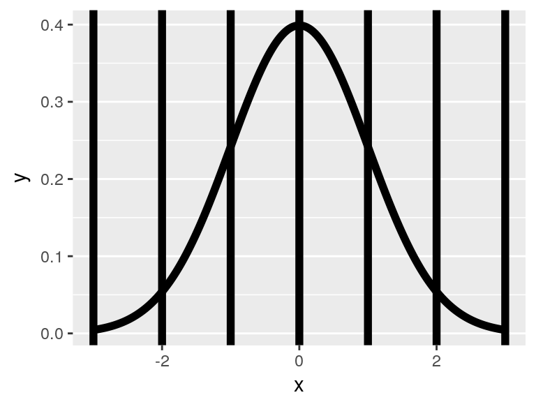

```r
# plot standard normal
x <- seq(-3, 3, length = 1000)
g <- ggplot(data.frame(x = x, y = dnorm(x)),
            aes(x = x, y = y)) + geom_line(size = 2)
g <- g + geom_vline(xintercept = -3 : 3, size = 2)
g
```

- for any $X \sim N(\mu, \sigma^2)$, calculating the number of standard deviations each observation is from the mean *converts* the random variable to a *standard normal* (denoted as $Z$ below)
  $$Z=\frac{X-\mu}{\sigma} \sim N(0,1)$$
- conversely, a standard normal can then be converted to *any normal distribution* by multiplying by standard deviation and adding the mean
  $$X = \mu + \sigma Z \sim N(\mu, \sigma^2)$$
- `qnorm(n, mean=mu, sd=sd)` = returns the $n^{th}$ percentiles for the given normal distribution
- `pnorm(x, mean=mu, sd=sd, lower.tail=F)` = returns the probability of an observation drawn from the given distribution is larger in value than the specified threshold $x$

## 8.1 Example

- the number of daily ad clicks for a company is (approximately) normally distributed with a mean of 1020 clicks/day and a standard deviation of 50 click/day
- What’s the probability of getting more than 1,160 clicks in a day?

```r
# calculate number of standard deviations from the mean
(1160 - 1020) / 50
```

```
## [1] 2.8
```

```r
# calculate probability using given distribution
pnorm(1160, mean = 1020, sd = 50, lower.tail = FALSE)
```

```
## [1] 0.00255513
```

```r
# calculate probability using standard normal
pnorm(2.8, lower.tail = FALSE)
```

```
## [1] 0.00255513
```

- therefore, it is not very likely (0.255513% chance), since 1,160 is 2.8 standard deviations from the mean
- What number of daily ad clicks would represent the one where 75% of days have fewer clicks (assuming days are independent and identically distributed)?

```r
qnorm(0.75, mean = 1020, sd = 50)
```

```
## [1] 1053.724
```

- therefore, 1054 would represent the threshold that has more clicks than 75% of days

# 9 Poisson Distribution

- used to model **counts**
  - mean = $\lambda$
  - variance = $\lambda$
  - PMF is defined as
    $$P(X = x; \lambda)=\frac{\lambda^xe^{-\lambda}}{x!}$$
    where $X = 0, 1, 2, ... \infty$
- some uses for Poisson distribution
  - modelling count data
  - modelling event-time or survival data $\rightarrow$ cancer trials, some patients never develop and some do, dealing with the data for both (“censoring”)
  - modelling contingency tables $\rightarrow$ record results for different characteristic measurements (eg. HAIR $\rightarrow$ “blonde”, “brunette”, “black” with BODY $\rightarrow$ “small”, “big”, “thin”)
  - approximating binomials when $n$ is large and $p$ is small (i.e. pollution on lung disease)
    - $X \sim Binomial(n, p)$
    - $\lambda = np$
  - modelling rates eg. rate of hard drive failures
    - $X \sim Poisson(\lambda t)$
    - $\lambda = E[X/t]$ is the expected count per unit of time
    - $t$ is the total monitoring time
- `ppois(n, lambda = lambda*t)` = returns probability of $n$ or fewer events happening given the rate $\lambda$ and time $t$

## 9.1 Example

- number of people that show up at a bus stop can be modeled with Poisson distribution with a mean of 2.5 per hour
- after watching the bus stop for 4 hours, what is the probability that 3 or fewer people show up for the whole time?

```r
# calculate using distribution
ppois(3, lambda = 2.5 * 4)
```

```
## [1] 0.01033605
```

- as we can see from above, there is a 1.0336051% chance for 3 or fewer people show up total at the bus stop during 4 hours of monitoring

## 9.2 Example - Approximating Binomial Distribution

- flip a coin with success probability of 0.01 a total 500 times (low $p$, large $n$)
- what’s the probability of 2 or fewer successes?

```r
# calculate correct probability from Binomial distribution (CDF)
pbinom(2, size = 500, prob = .01)
```

```
## [1] 0.1233858
```

```r
# estimate probability using Poisson distribution
ppois(2, lambda=500 * .01)
```

```
## [1] 0.124652
```

- as we can see from above, the two probabilities (12.3385774% vs 12.4652019%) are extremely close

# 10 Asymptotics

- **Intro**: Asymptotics refers to the behavior of estimators as the sample size goes to infinity. Our very notion of probability depends on the idea of asymptotics. For example, many people define probability as the proportion of times an event would occur in infinite repetitions. That is, the probability of a head on a coin is 50% because we believe that if we were to flip it infinitely many times, we would get exactly 50% heads (**Law of Large Numbers**).  
  We can use asymptotics to help to figure out things about distributions without knowing much about them to begin with. A profound idea along these lines is the **Central Limit Theorem**. It states that the distribution of averages is often normal, even if the distribution that the data is being sampled from is very non-normal. This helps us create robust strategies for creating statistical inferences when we’re not willing to assume much about the generating mechanism of our data.
- **asymptotics** = behavior of statistics as sample size $\rightarrow$ $\infty$
- useful for simple statistical inference/approximations
- form basis for frequentist interpretation of probabilities (“Law of Large Numbers”)

## 10.1 Law of Large Numbers (LLN)

- **LLN** states that an iid sample statistic that estimates a property of the sample (i.e. mean, variance) *converges to* the population statistic (i.e. population mean, population variance) as $n$ increases
- **Note**: an estimator is **consistent** if it converges to what it is estimating
- **LLN** states that sample mean/variance/standard deviation of iid samples are all *consistent estimators* for their population counterparts
  - $\bar X_n$ is average of the result of $n$ coin flips (i.e. the sample proportion of heads)
  - as we flip a fair coin over and over, it *eventually converges* to the true probability of a head

### 10.1.1 Example - LLN for Normal and Bernoulli Distribution

- for this example, we will simulate 10000 samples from the normal and Bernoulli distributions respectively
- we will plot the distribution of sample means as $n$ increases and compare it to the population means

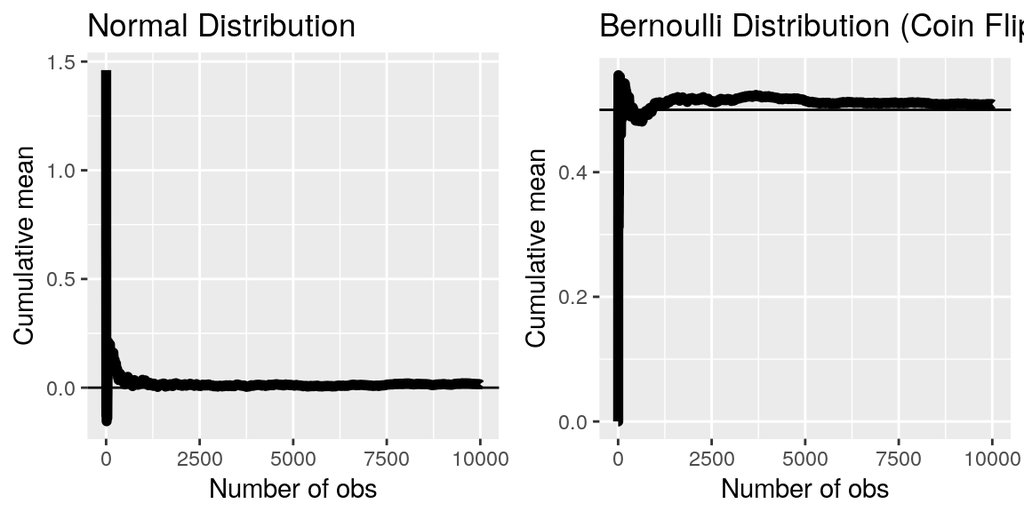

```r
# load library
library(gridExtra)
# specify number of trials
n <- 10000
# calculate sample (from normal distribution) means for different size of n
means <- cumsum(rnorm(n)) / (1:n)
# plot sample size vs sample mean
g <- ggplot(data.frame(x = 1:n, y = means), aes(x = x, y = y))
g <- g + geom_hline(yintercept = 0) + geom_line(size = 2)
g <- g + labs(x = "Number of obs", y = "Cumulative mean")
g <- g + ggtitle("Normal Distribution")

# calculate sample (coin flips) means for different size of n
means <- cumsum(sample(0 : 1, n , replace = TRUE)) / (1  : n)
# plot sample size vs sample mean
p <- ggplot(data.frame(x = 1 : n, y = means), aes(x = x, y = y))
p <- p + geom_hline(yintercept = 0.5) + geom_line(size = 2)
p <- p + labs(x = "Number of obs", y = "Cumulative mean")
p <- p + ggtitle("Bernoulli Distribution (Coin Flip)")
# combine plots
grid.arrange(g, p, ncol = 2)
```

- as we can see from above, for both distributions the sample means undeniably approach the respective population means as $n$ increases

## 10.2 Central Limit Theorem

- one of the most important theorems in statistics
- **CLT** states that the distribution of means of iid variables (properly normalized) approaches the standard normal as sample size $n$ increases
- in other words, for large values of $n$,
  $$\frac{\bar X_n - \mu}{\sigma / \sqrt{n}}=\frac{\sqrt n (\bar X_n - \mu)}{\sigma} = \frac{\mbox{Estimate} - \mbox{Mean of Estimate}}{\mbox{Std. Err. of Estimate}}$$
  has a distribution that of a standard normal.
- **Note**: Replacing the standard error by its estimated value doesn’t change the CLT
- **The useful way to think about the CLT is that $\bar X_n$ (= the sample mean, or means of $X_1,...,X_n$) is approximately $N(\mu, \sigma^2 / n)$**
  - distribution is centered at the population mean
  - with standard deviation = standard error of the mean
- typically the Central Limit Theorem can be applied when $n \geq 30$

### 10.2.1 Example - Result of our die rolling experiment

- Simulate a standard normal random variable by rolling $n$ times (six sided)
- Let $X_i$ be the outcome for die $i$
- Then note that $\mu = E[X_i] = 3.5$
- $Var(X_i) = 2.92$
- $\text{SE} \sqrt{2.92 / n} = 1.71 / \sqrt{n}$
- Lets roll $n$ dice, take their mean, subtract off $3.5$, and divide by $1.71 / \sqrt{n}$ and repeat this over and over

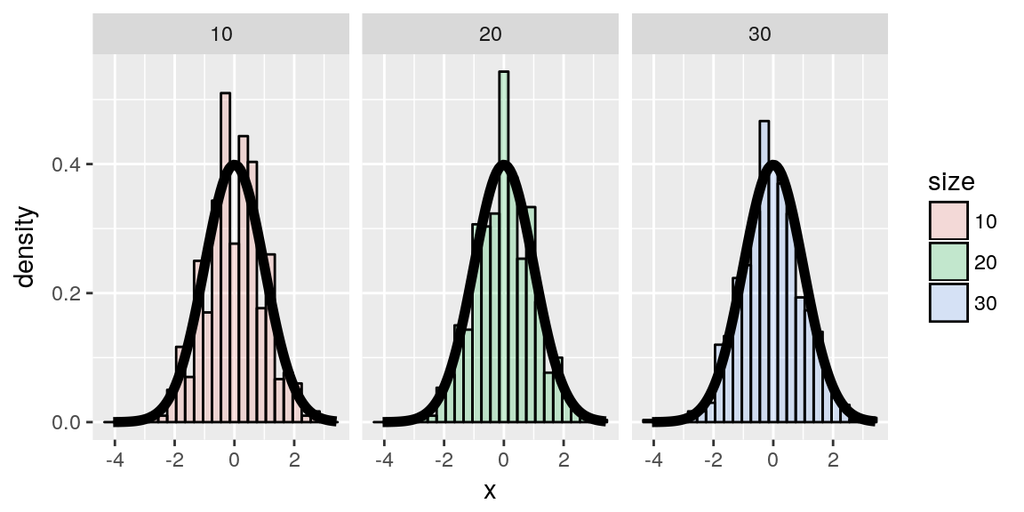

```r
nosim <- 1000
cfunc <- function(x, n) sqrt(n) * (mean(x) - 3.5) / 1.71
dat <- data.frame(
  x = c(apply(matrix(sample(1:6, nosim * 10, replace = TRUE), nosim), 1, cfunc, 10),
        apply(matrix(sample(1:6, nosim * 20, replace = TRUE), nosim), 1, cfunc, 20),
        apply(matrix(sample(1:6, nosim * 30, replace = TRUE), nosim), 1, cfunc, 30)),
  size = factor(rep(c(10, 20, 30), rep(nosim, 3))))
g <- ggplot(dat, aes(x = x, fill = size)) + geom_histogram(alpha = .20, binwidth=.3, colour = "black", aes(y = ..density..))
g <- g + stat_function(fun = dnorm, size = 2)
g + facet_grid(. ~ size)
```

### 10.2.2 Example - CLT with Bernoulli Trials (Coin Flips)

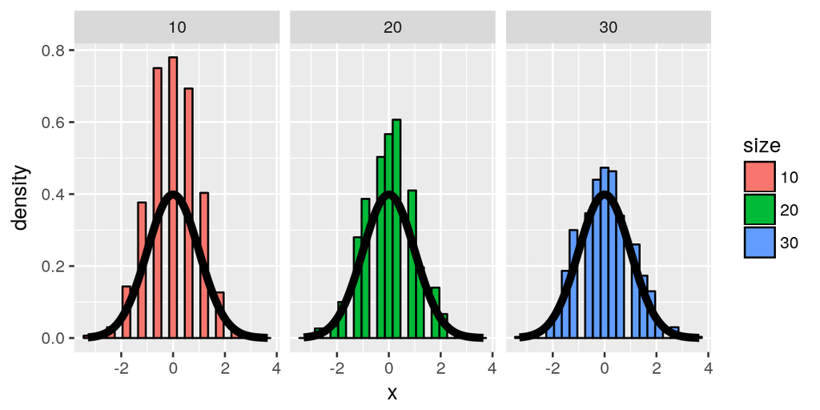

```r
# specify number of simulations
nosim <- 1000
# convert to standard normal
cfunc <- function(x, n) 2 * sqrt(n) * (mean(x) - 0.5)
# simulate data for sample sizes 10, 20, and 30
dat <- data.frame(
    x = c(apply(matrix(sample(0:1, nosim*10, replace=TRUE), nosim), 1, cfunc, 10),
        apply(matrix(sample(0:1, nosim*20, replace=TRUE), nosim), 1, cfunc, 20),
        apply(matrix(sample(0:1, nosim*30, replace=TRUE), nosim), 1, cfunc, 30)),
    size = factor(rep(c(10, 20, 30), rep(nosim, 3))))
# plot histograms for the trials
g <- ggplot(dat, aes(x = x, fill = size)) + geom_histogram(binwidth=.3,
    colour = "black", aes(y = ..density..))
# plot standard normal distribution for reference
g <- g + stat_function(fun = dnorm, size = 2)
# plot panel plots by sample size
g + facet_grid(. ~ size)
```

- now, we can run the same simulation trials for an extremely unfair coin with $p$ = 0.9

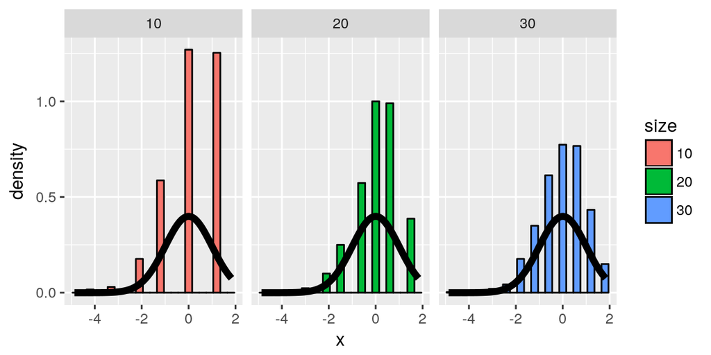

- as we can see from both simulations, the converted/standardized distribution of the samples convert to the standard normal distribution
- **Note**: speed at which the normalized coin flips converge to normal distribution depends on how biased the coin is (value of $p$)
- **Note**: CLT does not guarantee that the normal distribution will be a good approximation, but just that eventually it will be a good approximation as $n \rightarrow \infty$

# 11 Confidence Intervals

- **Intro**: When we estimate something using statistics, usually that estimate comes with uncertainty. Take, for example, election polling. When we get a polled percentage of voters that favor a candidate, we were only able to sample a small subset of voters. Therefore, our estimate has uncertainty associated with it.  
  Confidence intervals are a convenient way to communicate that uncertainty in estimates.

## 11.1 Confidence Intervals - Normal Distribution/Z Intervals

- **Z confidence interval** is defined as
  $$Estimate \pm ZQ \times SE_{Estimate}$$
  where $ZQ$ = quantile from the standard normal distribution
- according to CLT, the sample mean, $\bar X$, is approximately normal with mean $\mu$ and sd $\sigma / \sqrt{n}$
- **95% confidence interval for the population mean $\mu$** is defined as
  $$\bar X \pm 2\sigma/\sqrt{n}$$
  for the sample mean $\bar X \sim N(\mu, \sigma^2/n)$
  - you can choose to use 1.96 to be more accurate for the confidence interval
  - $P(\bar{X} > \mu + 2\sigma/\sqrt{n}~or~\bar{X} < \mu - 2\sigma/\sqrt{n}) = 5\%$
  - **interpretation**: if we were to repeatedly draw samples of size $n$ from the population and construct this confidence interval for each case, approximately 95% of the intervals will contain $\mu$
- confidence intervals get **narrower** with less variability or larger sample sizes
- **Example**
  - for this example, we will compute the 95% confidence interval for sons height data in inches

```r
# load son height data
data(father.son); x <- father.son$sheight
# calculate confidence interval for sons height in inches
mean(x) + c(-1, 1) * qnorm(0.975) * sd(x)/sqrt(length(x))
```

```
## [1] 68.51605 68.85209
```

## 11.2 Confidence Interval - Bernoulli Distribution/Wald Interval

- for Bernoulli distributions, $X_i$ is 0 or 1 with success probability $p$ and the variance is $\sigma^2 = p(1 - p)$
- the confidence interval takes the form of
  $$\hat{p} \pm z_{1-\alpha/2}\sqrt{\frac{p(1-p)}{n}}$$
- since the population proportion $p$ is unknown, we can use the sampled proportion of success $\hat{p} = X/n$ as estimate
- $p(1-p)$ is largest when $p = 1/2$, so 95% confidence interval can be calculated by
  $$\begin{aligned}
  \hat{p} \pm Z_{0.975} \sqrt{\frac{0.5(1-0.5)}{n}} & = \hat{p} \pm qnorm(.975) \sqrt{\frac{1}{4n}}\\
  & = \hat{p} \pm 1.96 \sqrt{\frac{1}{4n}}\\
  & = \hat{p} \pm \frac{1.96}{2} \sqrt{\frac{1}{n}}\\
  & \approx \hat{p} \pm \frac{1}{\sqrt{n}}\\
  \end{aligned}$$
  - this is known as the **Wald Confidence Interval** and is useful in *roughly estimating* confidence intervals
  - generally need $n$ = 100 for 1 decimal place, 10,000 for 2, and 1,000,000 for 3
- **Example**
  - suppose a random sample of 100 likely voters, 56 intent to vote for you, can you secure a victory?
  - we can use the Wald interval to quickly estimate the 95% confidence interval
  - as we can see below, because the interval [0.46, 0.66] contains values below 50%, victory is not guaranteed
  - `binom.test(k, n)$conf.int` = returns confidence interval binomial distribution (collection of Bernoulli trial) with `k` successes in `n` draws

```r
# define sample probability and size
p = 0.56; n = 100
# Wald interval
c("WaldInterval" = p + c(-1, 1) * 1/sqrt(n))
```

```
## WaldInterval1 WaldInterval2
##          0.46          0.66
```

```r
# 95% confidence interval
c("95CI" = p + c(-1, 1) * qnorm(.975) * sqrt(p * (1-p)/n))
```

```
##     95CI1     95CI2
## 0.4627099 0.6572901
```

```r
# perform binomial test
binom.test(56, n)$conf.int
```

```
## [1] 0.4571875 0.6591640
## attr(,"conf.level")
## [1] 0.95
```

## 11.3 Confidence Interval - Binomial Distribution/Agresti-Coull Interval

- for a binomial distribution with smaller values of $n$ (when $n$ < 30, thus not large enough for CLT), often time the normal confidence intervals, as defined by
  $$\hat{p} \pm z_{1-\alpha/2}\sqrt{\frac{p(1-p)}{n}}$$
  **do not** provide accurate estimates

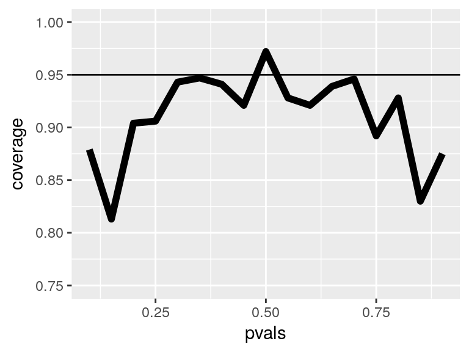

```r
# simulate 1000 samples of size 20 each
n <- 20; nosim <- 1000
# simulate for p values from 0.1 to 0.9
pvals <- seq(.1, .9, by = .05)
# calculate the confidence intervals
coverage <- sapply(pvals, function(p){
    # simulate binomial data (flipping n times and see how many successes there are, repeat nosim times)
    # phat = X/n (sampled proportion of success)
    phats <- rbinom(nosim, prob = p, size = n) / n
    # calculate lower 95% CI bound
    ll <- phats - qnorm(.975) * sqrt(phats * (1 - phats) / n)
    # calculate upper 95% CI bound
    ul <- phats + qnorm(.975) * sqrt(phats * (1 - phats) / n)
    # calculate percent of intervals that contain p
    mean(ll < p & ul > p)
})
# plot CI results vs 95%
ggplot(data.frame(pvals, coverage), aes(x = pvals, y = coverage)) + geom_line(size = 2) + geom_hline(yintercept = 0.95) + ylim(.75, 1.0)
```

- as we can see from above, the interval do not provide adequate coverage as 95% confidence intervals (frequently only provide 80 to 90% coverage)
- we can construct the **Agresti-Coull Interval**, which is defined uses the adjustment
  $$\hat{p} = \frac{X+2}{n+4}$$
  where we effectively *add 2 successes and 2 failures* to $X$
- therefore the interval becomes
  $$\frac{X+2}{n+4} \pm z_{1-\alpha/2}\sqrt{\frac{p(1-p)}{n}}$$
- **Note**: interval tend to be **conservative**
- **Example**

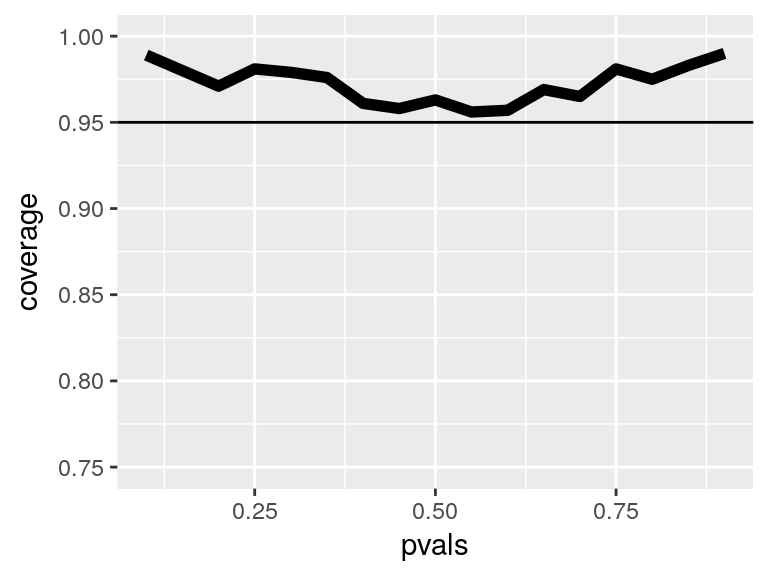

```r
# simulate 1000 samples of size 20 each
n <- 20; nosim <- 1000
# simulate for p values from 0.1 to 0.9
pvals <- seq(.1, .9, by = .05)
# calculate the confidence intervals
coverage <- sapply(pvals, function(p){
    # simulate binomial data with Agresti/Coull Interval adjustment
    # phat = (X + 2)/(n + 4)
    phats <- (rbinom(nosim, prob = p, size = n) + 2) / (n + 4)
    # calculate lower 95% CI bound
    ll <- phats - qnorm(.975) * sqrt(phats * (1 - phats) / n)
    # calculate upper 95% CI bound
    ul <- phats + qnorm(.975) * sqrt(phats * (1 - phats) / n)
    # calculate percent of intervals that contain p
    mean(ll < p & ul > p)
})
# plot CI results vs 95%
ggplot(data.frame(pvals, coverage), aes(x = pvals, y = coverage)) + geom_line(size = 2) + geom_hline(yintercept = 0.95) + ylim(.75, 1.0)
```

- as we can see from above, the coverage is much better for the 95% interval
- in fact, all of the estimates are more conservative as we previously discussed, indicating the Agresti-Coull intervals are *wider* than the regular confidence intervals

## 11.4 Confidence Interval - Poisson Interval

- $X \sim Poisson(\lambda t)$
  - We don’t observe $\lambda$, the rate, but we can estimate it, that is $\hat{\lambda} = X/t$
  - According to theory, the variance of the estimated rate is given by $Var(\hat{\lambda}) = \lambda/t$
  - Again, we don’t observe $\lambda$, but we can use our estimate of it instead. We approximate $Var(\hat{\lambda})$ as $\hat{\lambda}/t$ (= our (empirical) variance estimate)
- so the confidence interval is defined as
  $$\hat \lambda \pm z_{1-\alpha/2}\sqrt{\frac{\hat{\lambda}}{t}}$$
  - however, for small values of $\lambda$ (few events larger time interval), we **should not** use the asymptotic interval estimated
  - **Example**
    - for this example, we will go through a specific scenario as well as a simulation exercise to demonstrate the ineffectiveness of asymptotic intervals for small values of $\lambda$
    - nuclear pump failed 5 times out of 94.32 days, give a 95% confidence interval for the failure rate per day?
    - `poisson.test(x, T)$conf` = returns Poisson 95% confidence interval for given `x` occurrence over `T` time period

```r
# define parameters
x <- 5; t <- 94.32; lambda_hat <- x / t
# calculate confidence interval
round(lambda_hat + c(-1, 1) * qnorm(.975) * sqrt(lambda_hat / t), 3)
```

```
## [1] 0.007 0.099
```

```r
# return accurate confidence interval from poisson.test
poisson.test(x, T = 94.32)$conf
```

```
## [1] 0.01721254 0.12371005
## attr(,"conf.level")
## [1] 0.95
```

- **Example**: Simulating the Poisson coverage rate for **small lambda**

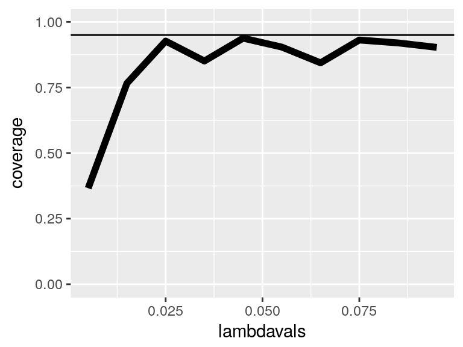

```r
# small lambda simulations
lambdavals <- seq(0.005, 0.10, by = .01); nosim <- 1000; t <- 100
# calculate coverage using Poisson intervals
coverage <- sapply(lambdavals, function(lambda){
    # calculate Poisson rates
    # lambda_hat = X/t (= estimate of the rate)
    lhats <- rpois(nosim, lambda = lambda * t) / t
    # lower bound of 95% CI
    ll <- lhats - qnorm(.975) * sqrt(lhats / t)
    # upper bound of 95% CI
    ul <- lhats + qnorm(.975) * sqrt(lhats / t)
    # calculate percent of intervals that contain lambda
    mean(ll < lambda & ul > lambda)
})
# plot CI results vs 95%
ggplot(data.frame(lambdavals, coverage), aes(x = lambdavals, y = coverage)) + geom_line(size = 2) + geom_hline(yintercept = 0.95)+ylim(0, 1.0)
```

- as we can see above, for small values of $\lambda = X/t$, the confidence interval produced by the asymptotic interval is *not* an accurate estimate of the actual 95% interval (not enough coverage)
- however, as $t \to \infty$, the interval becomes the *true 95% interval*

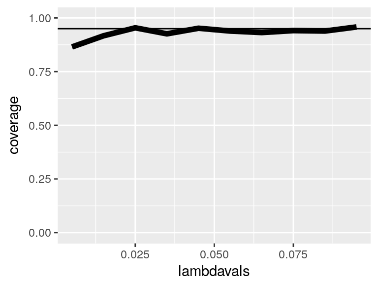

```r
# small lambda simulations
lambdavals <- seq(0.005, 0.10, by = .01); nosim <- 1000; t <- 1000
# calculate coverage using Poisson intervals
coverage <- sapply(lambdavals, function(lambda){
    # calculate Poisson rates
    # lambda_hat = X/t (= estimate of the rate)
    lhats <- rpois(nosim, lambda = lambda * t) / t
    # lower bound of 95% CI
    ll <- lhats - qnorm(.975) * sqrt(lhats / t)
    # upper bound of 95% CI
    ul <- lhats + qnorm(.975) * sqrt(lhats / t)
    # calculate percent of intervals that contain lambda
    mean(ll < lambda & ul > lambda)
})
# plot CI results vs 95%
ggplot(data.frame(lambdavals, coverage), aes(x = lambdavals, y = coverage)) + geom_line(size = 2) + geom_hline(yintercept = 0.95) + ylim(0, 1.0)
```

- as we can see from above, as $t$ increases, the Poisson intervals become closer to the actual 95% confidence intervals

## 11.5 Main Intake of LLN and CLT

- The LLN states that averages of iid samples converge to the population means that they are estimating
- The CLT states that averages are approximately normal, with distributions
  - centered at the population mean
  - with standard deviation equal to the standard error of the mean
  - CLT gives no guarantee that $n$ is large enough
- Taking the mean and adding and subtracting the relevant normal quantile times the SE yields a confidence interval for the mean
  - Adding and subtracting 2 SEs works for 95% intervals
- Confidence intervals get wider as the coverage increases
- Confidence intervals get narrower with less variability or larger sample sizes
- The Poisson and binomial case have exact intervals that don’t require the CLT
  - Poisson and binomial cases are discrete cases, and we saw that the CLT can sometimes not approximate their distributions well
    - see “Example: CLT with Bernoulli Trials (Biased Coin Flips)”
    - see “Example: Simulating the Poisson coverage rate for small lambda”
  - A quick fix for small sample size binomial calculations is to add 2 successes and failures

## 11.6 Confidence Intervals - t Distribution (Small Samples)

- statistical methods for dealing with small datasets
- **t** confidence interval is defined as
  $$Estimate \pm TQ \times SE_{Estimate} = \bar X \pm t_{n-1}\frac{S}{\sqrt{n}}$$
  - $TQ$ = quantile from T distribution
  - $t_{n-1}$ = relevant quantile
  - $t$ interval assumes data is iid normal so that
    $$\frac{\bar X - \mu}{S/\sqrt{n}}$$
    follows Gosset’s $t$ distribution with $n-1$ degrees of freedom
  - works well with data distributions that are roughly symmetric and mound shaped, and *does not* work with skewed distributions
    - for skewed distribution it doesn’t make a lot of sense to center the interval around the mean $\bar X$
    - in this case, consider taking logs or using a different summary like the median
  - paired observations (multiple measurements from same subjects) can be analyzed by t interval of differences
  - as more data collected (large degrees of freedom), t quantiles $\rightarrow$ z quantiles; therefore t interval $\rightarrow$ z interval (Central Limit Theorem)
  - `qt(0.975, df=n-1)` = calculate the relevant quantile using t distribution

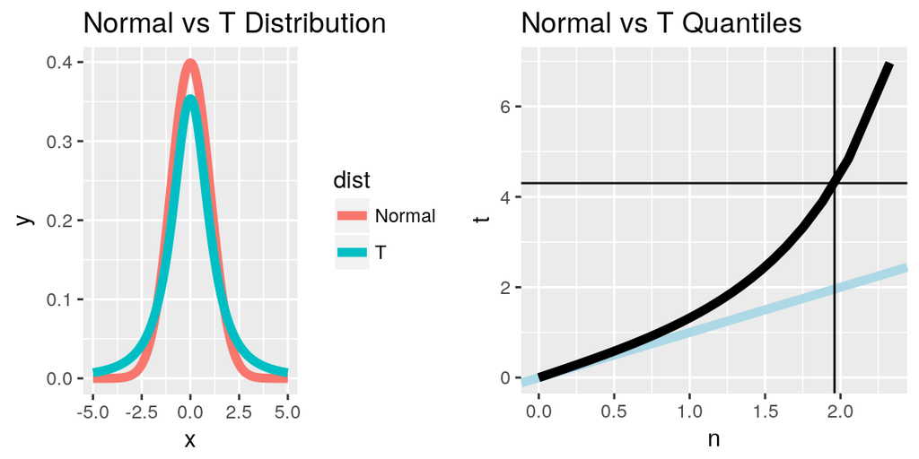

```r
# Plot normal vs t distributions (with 2 degrees of freedom)
k <- 1000; xvals <- seq(-5, 5, length = k); df <- 2
d <- data.frame(y = c(dnorm(xvals), dt(xvals, df)),x = xvals,
              dist = factor(rep(c("Normal", "T"), c(k,k))))
g <- ggplot(d, aes(x = x, y = y))
g <- g + geom_line(size = 2, aes(colour = dist)) + ggtitle("Normal vs T Distribution")

# compare normal vs t quantiles (with 2 degrees of freedom)
pvals <- seq(.5, .99, by = .01)
d <- data.frame(n= qnorm(pvals),t=qt(pvals, df),p = pvals)
h <- ggplot(d, aes(x= n, y = t))
h <- h + geom_abline(size = 2, col = "lightblue")
h <- h + geom_line(size = 2, col = "black")
h <- h + geom_vline(xintercept = qnorm(0.975))
h <- h + geom_hline(yintercept = qt(0.975, df)) + ggtitle("Normal vs T Quantiles")
# plot 2 graphs together
grid.arrange(g, h, ncol = 2)
```

- William Gosset’s **t** Distribution (“Student’s T distribution”)
  - student = Gosset’s pseudoname which he published under
  - indexed/defined by *degrees of freedom*, and becomes more like standard normal as degrees of freedom gets larger
  - thicker tails centered around 0, thus confidence interval = *wider* than Z interval (more mass concentrated away from the center)
  - for *small* sample size (value of n), normalizing the distribution by $\frac{\bar X - \mu}{S/\sqrt{n}}$ $\rightarrow$ t distribution, *not* the standard normal distribution
    - $S$ = standard deviation may be inaccurate, as the std of the data sample may not be truly representative of the population std
    - using the Z interval here thus may produce an interval that is too *narrow*

## 11.7 Confidence Interval - Paired t Tests

- compare observations for the same subjects over two different sets of data (i.e. different times, different treatments)
- the confidence interval is defined by
  $$\bar X_1 - \bar X_2 \pm t_{n-1}\frac{S}{\sqrt{n}}$$
  where $\bar X_1$ represents the first observations and $\bar X_2$ the second set of observations
- `t.test(difference)` = performs group mean t test and returns metrics as results, which includes the confidence intervals
  - `t.test(g2, g1, paired = TRUE)` = performs the same paired t test with data directly
  - `t.test(extra ~ I(relevel(group, 2)), paired = TRUE, data = sleep)$conf.int` = same as above, but returns confidence interval
- *Example*
  - the data used here is for a study of the effects of two soporific drugs (increase in hours of sleep compared to control) on 10 patients

```r
# load data
data(sleep)
head(sleep)
```

```
##   extra group ID
## 1   0.7     1  1
## 2  -1.6     1  2
## 3  -0.2     1  3
## 4  -1.2     1  4
## 5  -0.1     1  5
## 6   3.4     1  6
```

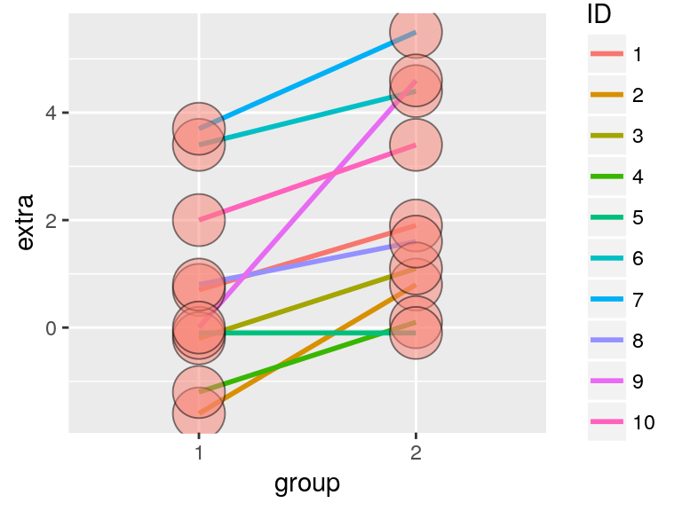

```r
# plot the first and second observations
g <- ggplot(sleep, aes(x = group, y = extra, group = factor(ID)))
g <- g + geom_line(size = 1, aes(colour = ID)) + geom_point(size =10, pch = 21, fill = "salmon", alpha = .5)
g
```

```r
# define groups
g1 <- sleep$extra[1 : 10]; g2 <- sleep$extra[11 : 20]
# define difference
difference <- g2 - g1

# calculate mean and sd of differences
mn <- mean(difference); s <- sd(difference); n <- 10

# calculate intervals manually
mn + c(-1, 1) * qt(.975, n-1) * s / sqrt(n)
```

```
## [1] 0.7001142 2.4598858
```

```r
# perform the same test to get confidence intervals (3 different syntaxes)
t.test(difference)
```

```
##
##  One Sample t-test
##
## data:  difference
## t = 4.0621, df = 9, p-value = 0.002833
## alternative hypothesis: true mean is not equal to 0
## 95 percent confidence interval:
##  0.7001142 2.4598858
## sample estimates:
## mean of x
##      1.58
```

```r
t.test(g2, g1, paired = TRUE)
```

```
##
##  Paired t-test
##
## data:  g2 and g1
## t = 4.0621, df = 9, p-value = 0.002833
## alternative hypothesis: true difference in means is not equal to 0
## 95 percent confidence interval:
##  0.7001142 2.4598858
## sample estimates:
## mean of the differences
##                    1.58
```

```r
t.test(extra ~ I(relevel(group, 2)), paired = TRUE, data = sleep)
```

```
##
##  Paired t-test
##
## data:  extra by I(relevel(group, 2))
## t = 4.0621, df = 9, p-value = 0.002833
## alternative hypothesis: true difference in means is not equal to 0
## 95 percent confidence interval:
##  0.7001142 2.4598858
## sample estimates:
## mean of the differences
##                    1.58
```

```r
# Reformat the results
rbind(
mn + c(-1, 1) * qt(.975, n-1) * s / sqrt(n),
as.vector(t.test(difference)$conf.int),
as.vector(t.test(g2, g1, paired = TRUE)$conf.int),
as.vector(t.test(extra ~ I(relevel(group, 2)), paired = TRUE, data = sleep)$conf.int)
)
```

```
##           [,1]     [,2]
## [1,] 0.7001142 2.459886
## [2,] 0.7001142 2.459886
## [3,] 0.7001142 2.459886
## [4,] 0.7001142 2.459886
```

## 11.8 Independent Group t Intervals - Equal Variances

- compare two groups in randomized trial (“A/B Testing”): eg. mean blood pressure between two groups in a randomized trial; those who received the treatment to those who received a placebo
- cannot use the paired t test because the groups are **independent** and may have **different sample sizes** (not matched)
- perform randomization to balance unobserved covariance that may otherwise affect the result
- $t$ confidence interval for $\mu_y - \mu_x$ is defined as
  $$\bar Y - \bar X \pm t_{n_x + n_y - 2, 1 - \alpha/2}S_p\left(\frac{1}{n_x} + \frac{1}{n_y}\right)^{1/2}$$
  - $t_{n_x + n_y - 2, 1 - \alpha/2}$ = relevant quantile
  - $n_x + n_y - 2$ = degrees of freedom
  - $S_p\left(\frac{1}{n_x} + \frac{1}{n_y}\right)^{1/2}$ = standard error
  - $S_p^2 = \{(n_x - 1) S_x^2 + (n_y - 1) S_y^2\}/(n_x + n_y - 2)$ = pooled variance estimator
    - this is effectively a weighted average between the two variances, such that different sample sizes are taken in to account
    - For equal sample sizes, $n_x = n_y$, $S_p^2 = \frac{S_x^2 + S_y^2}{2}$ (average of variance of two groups)
  - **Note:** this interval assumes **constant variance** across two groups; if variance is different, use the next interval
- *Example* (based on Rosner, Fundamentals of Biostatistics):
  - Comparing SBP for 8 oral contraceptive users versus 21 controls
  - $\bar X_{OC} = 132.86$ mmHg with $s_{OC} = 15.34$ mmHg
  - $\bar X_{C} = 127.44$ mmHg with $s_{C} = 18.23$ mmHg

```r
# Pooled variance estimate
sp <- sqrt((7 * 15.34^2 + 20 * 18.23^2) / (8 + 21 - 2))
# t confidence interval
132.86 - 127.44 + c(-1, 1) * qt(.975, 27) * sp * (1 / 8 + 1 / 21)^.5
```

```
## [1] -9.521097 20.361097
```

- *Revisit Example*: Mistakenly treating the **sleep data** as grouped

```r
n1 <- length(g1); n2 <- length(g2)
# Pooled variance estimate
sp <- sqrt( ((n1 - 1) * sd(g1)^2 + (n2-1) * sd(g2)^2) / (n1 + n2-2))
# mean difference
md <- mean(g2) - mean(g1)
# standard error of mean difference
semd <- sp * sqrt(1 / n1 + 1/n2)
rbind(
# Independent Group t Intervals - Equal Variance
md + c(-1, 1) * qt(.975, n1 + n2 - 2) * semd,
t.test(g2, g1, paired = FALSE, var.equal = TRUE)$conf,
# paired t test from previous example
t.test(g2, g1, paired = TRUE)$conf
)
```

```
##            [,1]     [,2]
## [1,] -0.2038740 3.363874
## [2,] -0.2038740 3.363874
## [3,]  0.7001142 2.459886
```

- *Example*: Chicken Weights (assumption of equal variances)

```r
library(datasets); data(ChickWeight); library(reshape2)
# define weight gain or loss
wideCW <- dcast(ChickWeight, Diet + Chick ~ Time, value.var = "weight")
# some renaming
names(wideCW)[-(1 : 2)] <- paste("time", names(wideCW)[-(1 : 2)], sep = "")
library(dplyr)
# calculate change of weight (difference of weights at final and initial time)
wideCW <- mutate(wideCW,
  gain = time21 - time0
)
```

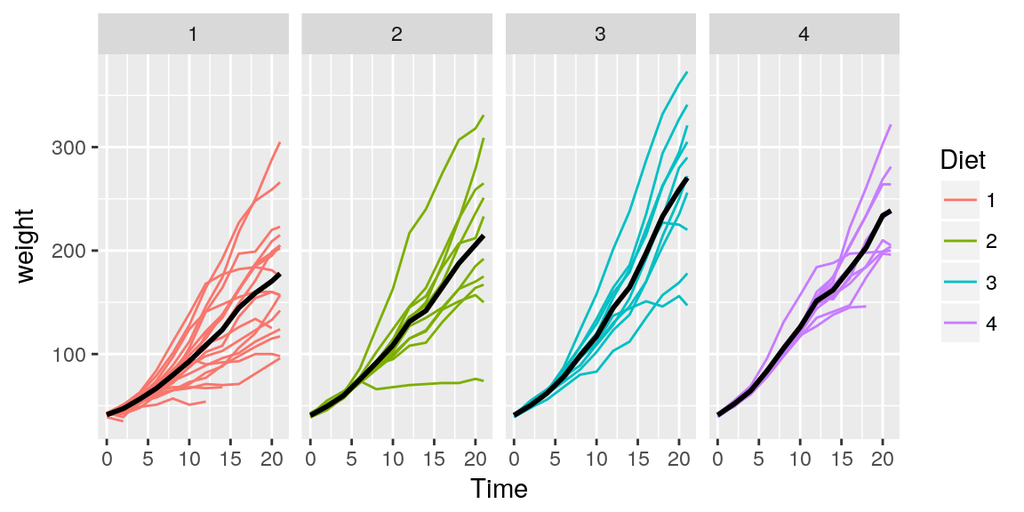

```r
# plotting using spaghetti plot
# black line is the mean for each of the groups
g <- ggplot(ChickWeight, aes(x = Time, y = weight,
                             colour = Diet, group = Chick))
g <- g + geom_line()
g <- g + stat_summary(aes(group = 1), geom = "line", fun.y = mean, size = 1, col = "black")
g <- g + facet_grid(. ~ Diet)
g
```

- As can be seen above, group on diet 1 is more spread out than group 4
  - it does also appear that the average weight gain for the first diet does appear to be a little bit slower than the average weight gain for the fourth diet

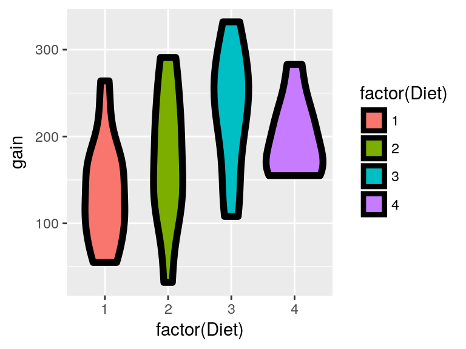

```r
# Weight gain by diet using a violin plot
# Weight gain = end weight - the baseline weight by each of the diets
g <- ggplot(wideCW, aes(x = factor(Diet), y = gain, fill = factor(Diet)))
g <- g + geom_violin(col = "black", size = 2)
g
```

- As indicated by the graph above, if we compare first diet with the fourth diet, it seems our **assumption of equal variances** appears suspect here
  - Let’s do a t interval (w/ and w/o assumption of equal variances)

```r
# Compare first diet and fourth diet only -> subsetting
wideCW14 <- subset(wideCW, Diet %in% c(1, 4))

# t testing w/ and w/o assumption of equal variances
rbind(
t.test(gain ~ Diet, paired = FALSE, var.equal = TRUE, data = wideCW14)$conf,
t.test(gain ~ Diet, paired = FALSE, var.equal = FALSE, data = wideCW14)$conf
)
```

```
##           [,1]      [,2]
## [1,] -108.1468 -14.81154
## [2,] -104.6590 -18.29932
```

- In both cases the intervals are entirely below zero, suggesting less weight gain on diet one than on diet four
  - However, the specific interval does change depending on whether the variances are equal or not
  - Not enough information about the specific dataset to ascertain whether that’s a substantive change or not

## 11.9 Independent Group t Intervals - Unequal Variances

- Under unequal variances with confidence interval for $\mu_y - \mu_x$ defined as
  $$\bar Y - \bar X \pm t_{df} \times \left(\frac{s_x^2}{n_x} + \frac{s_y^2}{n_y}\right)^{1/2}$$
  where $t_{df}$ is the relevant quantile calculated with degrees of freedom
  $$df = \frac{\left(S_x^2 / n_x + S_y^2/n_y\right)^2}
  {\left(\frac{S_x^2}{n_x}\right)^2 / (n_x - 1) +
  \left(\frac{S_y^2}{n_y}\right)^2 / (n_y - 1)}$$
  will be approximately a 95% interval
  - This works really well; so when in doubt, just assume unequal variances
  - $\left(\frac{s_x^2}{n_x} + \frac{s_y^2}{n_y}\right)^{1/2}$ = standard error
  - **Note**: normalized statistic does not follow t distribution but can be approximated through the formula with df
- *Revisit Example*:
  - Comparing SBP for 8 oral contraceptive users versus 21 controls
  - $\bar X_{OC} = 132.86$ mmHg with $s_{OC} = 15.34$ mmHg
  - $\bar X_{C} = 127.44$ mmHg with $s_{C} = 18.23$ mmHg
  - $df=15.04$, $t_{15.04, .975} = 2.13$
  - Interval
    $$132.86 - 127.44 \pm 2.13 \left(\frac{15.34^2}{8} + \frac{18.23^2}{21} \right)^{1/2}
    = [-8.91, 19.75]$$
  - In R, `t.test(..., var.equal = FALSE)`
- Comparing other kinds of data
  - For binomial data, there’s lots of ways to compare two groups:
    - relative risk, risk difference, odds ratio
    - Chi-squared test, normal approximations, exact tests
  - For count data, there’s also Chi-squared tests and exact tests.

# 12 Hypothesis Testing

- **Intro**: Deciding between two hypotheses is a core activity in scientific discovery. Statistical hypothesis testing is the formal inferential framework around choosing between hypotheses.

## 12.1 Theoretical Foundation

- Hypothesis testing is concerned with making decisions about populations using observed data
  - **null** hypothesis (**$H_0$**) represents the status quo
  - **$H_0$** assumed to be *true* $\rightarrow$ statistical evidence required to reject it for **alternative** or “research” hypothesis (**$H_a$**)
    - alternative hypothesis typically take form of >, < or $\ne$
  - **Results**: there are four possible outcomes of our statistical decision process

| Truth | Decide | Result |
| --- | --- | --- |
| $H_0$ | $H_0$ | Correctly accept null |
| $H_0$ | $H_a$ | Type I error: Reject a TRUE $H_0$ (measured by $\alpha$) |
| $H_a$ | $H_a$ | Correctly reject null (measured by **power** |
| $H_a$ | $H_0$ | Type II error: Accepts a FALSE $H_0$ (measured by $\beta$) |

- *Example*: Distinguish between Type I and Type II error
  - Consider a court of law
  - $H_0$: defendant is innocent
  - We require a standard on the available evidence to reject the $H_0$ (ie. convict)
  - If we set a low standard, then we would increase the percentage of innocent people convicted (type I errors)
    - however we would also increase the percentage of guilty people convicted (correctly rejecting the null)
  - If we set a high standard, then we increase the the percentage of innocent people let free (correctly accepting the null)
    - however we would also increase the percentage of guilty people let free (type II errors)
- **$\alpha$** = Type I error rate
  - = probability of *rejecting* the null hypothesis when, in fact, the null is *correct*
  - Consider our sleep example again
    - Reject the null hypothesis if $\bar X$ was larger than some constant, say $C$
    - Typically, $C$ is chosen so that the probability of a Type I error, $\alpha$, is $.05$ (or some other relevant constant)
  - $\alpha$ = 0.05 $\rightarrow$ standard for hypothesis testing
  - **Note**: as Type I error rate increases, Type II error rate decreases and vice versa
- For large samples (large n), use the **Z Test** for $H_0:\mu = \mu_0$
  - **$H_a$:**
    - $H_1: \mu < \mu_0$
    - $H_2: \mu \neq \mu_0$
    - $H_3: \mu > \mu_0$
  - Test statistic $TS = \frac{\bar{X} - \mu_0}{S / \sqrt{n}}$
  - Reject the null hypothesis $H_0$ when
    - $H_1: TS \leq Z_{\alpha} = -Z_{1 - \alpha}$
    - $H_2: |TS| \geq Z_{1 - \alpha / 2}$
    - $H_3: TS \geq Z_{1 - \alpha}$
  - **Note**: In case of $\alpha$ = 0.05 (most common), $Z_{1-\alpha}$ = 1.645 (95 percentile)
  - $\alpha$ is set low, so that when $H_0$ is rejected, there is a low probabilty that we have made an error
  - We have not fixed the probability of a type II error, $\beta$; therefore we tend to say “Fail to reject $H_0$” rather than accepting $H_0$
- For small samples (small n), use the **T Test** for $H_0:\mu = \mu_0$
  - **$H_a$:**
    - $H_1: \mu < \mu_0$
    - $H_2: \mu \neq \mu_0$
    - $H_3: \mu > \mu_0$
  - Test statistic $TS = \frac{\bar{X} - \mu_0}{S / \sqrt{n}}$
  - Reject the null hypothesis $H_0$ when
    - $H_1: TS \leq T_{\alpha} = -T_{1 - \alpha}$
    - $H_2: |TS| \geq T_{1 - \alpha / 2}$
    - $H_3: TS \geq T_{1 - \alpha}$
  - **Note**: In case of $\alpha$ = 0.05 (most common), $T_{1-\alpha}$ = `qt(.95, df = n-1)`
- **rejection region** = region of TS values for which you reject $H_0$
- **power** = probability of rejecting $H_0$ when it is false
  - power is used to calculate sample size for experiments
- The **test statistic** tells us how many standard deviations the sample mean is from the hypothesized one
- **two-sided tests** $\rightarrow$ $H_a: \mu \neq \mu_0$
  - reject $H_0$ only if test statistic is too large or too small
  - for $\alpha$ = 0.05, split equally to 2.5% for upper and 2.5% for lower tails
    - equivalent to $|TS| \geq T_{1 - \alpha / 2}$
    - example: for T test, `qt(.975, df)` and `qt(.025, df)`
  - **Note**: failing to reject one-sided test = fail to reject two-sided
- R commands for T test:
  - `t.test(x)`
    - `alternative` argument can be used to specify one-sided tests: `less` or `greater`
    - `alternative` default = `two-sided`
  - output:
    - test statistic (`t`), degrees of freedom (`df`), `p-value`, 95% confidence interval, and mean of sample
    - confidence interval in units of data can be used to intepret the practical significance of the results
- **t tests and confidence intervals**
  - Consider testing $H_0: \mu = \mu_0$ versus $H_a: \mu \neq \mu_0$
  - ($1-\alpha$)% confidence interval for $\mu$ = set of all possible values that fail to reject $H_0$
  - therefore if ($1-\alpha$)% confidence interval contains $\mu_0$, then we fail to reject $H_0$
- **two-group intervals testing**
  - Rejection rules the same
  - Test $H_0: \mu_1 = \mu_2$ $\Leftrightarrow$ $H_0: \mu_1 - \mu_2 = 0$
  - Test statistic (assuming equal variance):
    $$TS = \frac{Estimate - H_0 Value}{SE_{Estimate}} = \frac{\bar X_1 - \bar X_2 - 0}{S_p\left(\frac{1}{n_x} + \frac{1}{n_y}\right)^{1/2}}$$
    - $S_p^2 = \{(n_x - 1) S_x^2 + (n_y - 1) S_y^2\}/(n_x + n_y - 2)$ = pooled variance estimator
  - Test statistic (assuming unequal variance):
    $$TS = \frac{Estimate - H_0 Value}{SE_{Estimate}} = \frac{\bar X_1 - \bar X_2 - 0}{\left(\frac{s_x^2}{n_x} + \frac{s_y^2}{n_y}\right)^{1/2}}$$
  - R Command
    - `t.test(values ~ factor, paired = FALSE, var.equal = TRUE, data = data)`
      - `paired = FALSE` = independent values
      - `factor` argument must have only two levels

## 12.2 Example - Hypothesis Testing (large sample size $n$)

- A respiratory disturbance index of more than $30$ events / hour, say, is considered evidence of severe sleep disordered breathing (SDB)
- Suppose that in a sample of $100$ overweight subjects with other risk factors for sleep disordered breathing at a sleep clinic, the mean RDI was $32$ events / hour with a standard deviation of $10$ events / hour.
- We might want to test the hypothesis that
  - $H_0 : \mu = 30$
  - $H_a : \mu > 30$
  - where $\mu$ is the population mean RDI.
- Standard error of the mean $10 / \sqrt{100} = 1$
- Under $H_0$ $\bar X \sim N(30, 1)$
- We want to chose $C$ so that the $P(\bar X > C; H_0)$ is 5%
- The 95th percentile of a normal distribution is 1.645 standard deviations from the mean
- If $C = 30 + 1 \times 1.645 = 31.645$
  - Then the probability that a $N(30, 1)$ is larger than $C$ is 5%
  - So the rule “Reject $H_0$ when $\bar X \geq 31.645$” has the property that the probability of rejection is 5% when $H_0$ is true (for the $\mu_0$, $\sigma$ and $n$ given)
- In general we don’t convert $C$ back to the original scale
  - We would just **reject** using the Z-score; which is how many standard errors the sample mean is above the hypothesized mean
    $$\frac{32 - 30}{10 / \sqrt{100}} = 2$$
    is greater than $1.645$
  - Or, whenever $\sqrt{n} (\bar X - \mu_0) / s > Z_{1-\alpha}$

## 12.3 Example - Hypothesis Testing (small sample size $n$)

- Consider our example again. Suppose that $n= 16$ (rather than $100$)
- The statistic
  $$\frac{\bar X - 30}{s / \sqrt{16}}$$
  follows a $T$ distribution with 15 df under $H_0$
- Under $H_0$, the probability that it is larger than the 95th percentile of the $T$ distribution is 5%
- The 95th percentile of the T distribution with 15 df is 1.7530504 (obtained via `qt(.95, 15)`)
- So that our test statistic is now $\sqrt{16}(32 - 30) / 10 = 0.8$
- We now **fail to reject**

## 12.4 Example - Hypothesis Testing (Two sided tests)

- Suppose that we would reject the null hypothesis if in fact the mean was too large or too small
- That is, we want to test the alternative $H_a : \mu \neq 30$
- We will reject if the test statistic, $\sqrt{16}(32 - 30) / 10 = 0.8$, is either too large or too small
- Then we want the probability of rejecting under the null to be 5%, split equally as 2.5% in the upper tail and 2.5% in the lower tail
- Thus we reject if our test statistic is larger than `qt(.975, 15)` = 2.1314495 or smaller than `qt(.025, 15)` = -2.1314495
- So we **fail to reject** the two sided test as well
- (If you fail to reject the one sided test, you know that you will fail to reject the two sided)

## 12.5 Example - Hypothesis Testing (Two-group intervals testing)

- Consider the Chicken weight example in Section 11.8

```r
library(datasets); data(ChickWeight); library(reshape2)
# define weight gain or loss
wideCW <- dcast(ChickWeight, Diet + Chick ~ Time, value.var = "weight")
# some renaming
names(wideCW)[-(1 : 2)] <- paste("time", names(wideCW)[-(1 : 2)], sep = "")
library(dplyr)
# calculate change of weight (difference of weights at final and initial time)
wideCW <- mutate(wideCW,
  gain = time21 - time0
)

# Equal variance T test comparing diets 1 and 4
wideCW14 <- subset(wideCW, Diet %in% c(1, 4))
t.test(gain ~ Diet, paired = FALSE, var.equal = TRUE, data = wideCW14)
```

```
##
##  Two Sample t-test
##
## data:  gain by Diet
## t = -2.7252, df = 23, p-value = 0.01207
## alternative hypothesis: true difference in means is not equal to 0
## 95 percent confidence interval:
##  -108.14679  -14.81154
## sample estimates:
## mean in group 1 mean in group 4
##        136.1875        197.6667
```

- We can **reject** the $H_0: \mu_1 - \mu_2 = 0$, by looking at $t$ (very low), the 95% confidence interval, or the p-value

# 13 P-Values

- **Intro**: P-values are a convenient way to communicate the results of a hypothesis test. When communicating a P-value, the reader can perform the test at whatever Type I error rate that they would like. Just compare the P-value to the desired Type I error rate and if the P-value is smaller, reject the null hypothesis.  
  Formally, the P-value is the probability of getting data as or more extreme than the observed data in favor of the alternative. The probability calculation is done assuming that the null is true. In other words if we get a very large T statistic the P-value answers the question “How likely would it be to get a statistic this large or larger if the null was actually true?”. If the answer to that question is “very unlikely”, in other words the P-value is very small, then it sheds doubt on the null being true, since you actually observed a statistic that extreme.

## 13.1 Exact Binomial Test: Why using p-values?

- Recall this problem, *Suppose a friend has $8$ children, $7$ of which are girls and none are twins*
- Perform the relevant hypothesis test. $H_0 : p = 0.5$ $H_a : p > 0.5$
  - What is the relevant rejection region so that the probability of rejecting is (less than) 5%?

| Rejection region | Type I error rate |
| --- | --- |
| [0 : 8] | 1 |
| [1 : 8] | 0.9960938 |
| [2 : 8] | 0.9648438 |
| [3 : 8] | 0.8554688 |
| [4 : 8] | 0.6367187 |
| [5 : 8] | 0.3632813 |
| [6 : 8] | 0.1445313 |
| [7 : 8] | 0.0351563 |
| [8 : 8] | 0.0039062 |

- It’s impossible to get an exact 5% level test for this case due to the discreteness of the binomial.
  - The closest is the rejection region [7 : 8]
  - Any alpha level lower than 0.0039062 is not attainable.
  - Since your friend has 7 girls out of 8 children, we **reject** the $H_0$
- For larger sample sizes, we could do a normal approximation, but you already knew this.
- A two-sided test would mean that our alternative hypothesis is that p is not equal to .5, and it’s not obvious how to do this with a binomial distribution
  - Given a way to do two sided tests, we could take the set of values of $p_0$ for which we fail to reject to get an exact binomial confidence interval (called the Clopper/Pearson interval, BTW)
- For these problems, people always create a P-value (next lecture) rather than computing the rejection region.

## 13.2 Theoretical Foundation

- **Idea**: Suppose nothing is going on - how unusual is it to see the estimate we got?
  - **Approach**:
    1. Define the hypothetical distribution of a data summary (statistic) when “nothing is going on” (*null hypothesis*). In other words, we start with a null hypothesis which is a reasoned guess at some distribution of a statistic
    2. Calculate the summary statistic from the given data (*test statistic*)
    3. Compare what we calculated to our hypothetical distribution and see if the value is “extreme” (*p-value*)
  - Your comparison tells you how “extreme” the test value is toward the alternative hypothesis.
- **p-value**
  - most common measure of “statistical significance”
  - = probability under the null hypothesis of obtaining evidence as extreme or more than that obtained
    - Given that $H_0$ is true, how likely is it to obtain the result (test statistic), how unusual or extreme is the sample value we get from our data?
  - if p-value is small, then either $H_0$ is true AND the obeserved is a rare event (very unlikely) **OR** $H_0$ is false
- *Example*:
  - Suppose that you get a $T$ statistic of $2.5$ for 15 df testing $H_0:\mu = \mu_0$ versus $H_a : \mu > \mu_0$.
  - What’s the probability of getting a $T$ statistic as large or more as $2.5$?

  `r pt(2.5, 15, lower.tail = FALSE)`

  `## [1] 0.0122529`
  - Therefore, the probability of seeing evidence as extreme or more extreme than that actually obtained under $H_0$ is 0.0122529. So either the $H_0$ is true, and we’ve seen an exceptionally large T statistic, or the $H_0$ is false.
- **attained significance level** = smallest value for $\alpha$ for which you will still reject the $H_0$ $\rightarrow$ equivalent to p-value (but philosophically a little bit different)
  - By reporting a P-value the reader can perform the hypothesis test at whatever $\alpha$ level he or she choses
  - if p-value < $\alpha$ $\rightarrow$ reject $H_0$
  - for two-sided tests, double the smaller of the two one sided hypothesis test p-values
  - (Software most often report p-value for two-sided tests)
- R Command
  - p-value = `pt(statistic, df, lower.tail = FALSE)`
    - `lower.tail = FALSE` = returns the probability of getting a value from the t distribution that is larger than the test statistic
  - Binomial (coin flips)
    - probability of getting x results out of n trials and event probability of p = `pbinom(x-1, size = n, prob = p, lower.tail = FALSE)`
    - `x-1` is used here because the upper tail includes the specified number (since we want greater than x, we start at x - 1)
    - two-sided interval (testing for $\ne$): find the smaller of two one-sided intervals (X < value, X > value), and double the result (in R: `pnorm(-abs(ts))` gives the smaller value)
    - **Note**: `lower.tail = FALSE` = strictly greater
  - Poisson
    - probability of getting x results given the rate r = `ppois(x-1, rate, lower.tail = FALSE)`
    - `x-1` is used here because the upper tail includes the specified number (since we want greater than x, we start at x - 1)
    - `rate` = events that should occur given the rate (multiplied by 100 to yield an integer)
    - **Note**: `lower.tail = FALSE` = strictly greater

## 13.3 Example - Binomial Case

- Suppose a friend has $8$ children, $7$ of which are girls and none are twins
- If each gender has an independent $50$% probability for each birth, what’s the probability of getting $7$ or more girls out of $8$ births?
- $H_0: p=0.5$ versus $H_a: p>0.5$

```r
choose(8, 7) * .5 ^ 8 + choose(8, 8) * .5 ^ 8
```

```
## [1] 0.03515625
```

```r
pbinom(6, size = 8, prob = .5, lower.tail = FALSE)
```

```
## [1] 0.03515625
```

- Therefore **reject** $H_0$ at the 5% level, at the 4% level, but we would not reject at an type 1 error rate of 3%
- To calculate the two-sided p-value ($H_0: p=0.5$ versus $H_a: p \neq 0.5$), use a simple trick: calculate the two one-sided p values and double the smaller one:
  - the probability of being 7 or larger would be one one-sided p value, and
  - the probability of being 7 or smaller would be the other one-sided p-value

## 13.4 Example - Poisson Case

- Suppose that a hospital has an infection rate of 10 infections per 100 person/days at risk (rate of 0.1) during the last monitoring period
- Assume that an infection rate of 0.05 is an important benchmark
- Given the model, could the observed rate being larger than 0.05 be attributed to chance?
- Under $H_0: \lambda = 0.05$ so that $\lambda_0 100 = 5$
- Consider $H_a: \lambda > 0.05$.

```r
ppois(9, 5, lower.tail = FALSE)
```

```
## [1] 0.03182806
```

```r
# alternatively
poisson.test(10, T = 100, r = 0.05, alt="greater")$p.value
```

```
## [1] 0.03182806
```

- The calculated value above is the probability of obtaining 10 or more infections if, in fact, the true rate of infections we’ve should’ve seen on a 100 person days at risk is 5
- It turns out that’s a relatively low probability. It’s unlikely for us to have seen as many as 10 infections for a 100 person days at risk.
- So only 3% chance of that occurring, if, in fact, the real infection was 5 for a 100 person days at risk. So this hospital perhaps should execute those quality control procedures

# 14 Power

- **Intro**: We’ve talked about a Type I error, rejecting the null hypothesis when it’s true. We’ve structured our hypothesis test so that the probability of this happening is small. The other kind of error we could make is to fail to reject when the alternative is true (Type II error). Or we might think about the probability of rejecting the null when it is false. This is called Power = 1 - Type II error. We don’t have as much control over this probability, since we’ve spent all of our flexibility guaranteeing that the Type I error rate is small.  
  One avenue for the control of power is at the design phase. There, assuming our finances let us, we can pick a large enough sample size so that we’d be likely to reject if the alternative is true. Thus the most frequent use of power is to help us design studies.
- **Power** = probability of rejecting the null hypothesis when it is false (the more power the better)
  - most often used in designing studies so that there’s a reasonable chance to detect the alternative hypothesis if the alternative hypothesis is true
- $\beta$ = probability of type II error = failing to reject the null hypothesis when it’s false
- power = $1 - \beta$
- *Revisit Example*: Respiratory Distress Index and sleep disturbances
  - $H_0: \mu = 30$ versus $H_a: \mu > 30$
  - Power is the probability that the true mean mu is greater than the (1-alpha) quantile or `qnorm(.95)`
  - Power:
    $$Power = P\left(\frac{\bar X - 30}{s /\sqrt{n}} > t_{1-\alpha,n-1} ~;~ \mu = \mu_a \right)$$
    - **Note**: the above function depends on the specific value of $\mu_a$, eg. $\mu_a=30$ versus $\mu_a=60$
    - **Note**: as $\mu_a$ approaches 30, power approaches $\alpha$  
      $P\left(\frac{\bar X - 30}{s /\sqrt{n}} > t_{1-\alpha,n-1} ~;~ \mu_a = 30 \right) = \alpha$
  - Key point: The two hypotheses, $H_0$ and $H_a$, actually represent two distributions since they’re talking about means or centers of distributions:
    - $H_0$ says that the mean is $\mu_0$ (30 in our example) and
    - $H_a$ says that the mean is $\mu_a$.
  - Now, assuming the sample mean is normally distributed and asssuming equal variance, $H_0$ is rejected when $\frac{\bar X - 30}{\sigma /\sqrt{n}} > Z_{1-\alpha}$
    - or equivalently, $\bar X > 30 + Z_{1-\alpha} \frac{\sigma}{\sqrt{n}}$
    - Under $H_0: \bar X \sim N(\mu_0, \sigma^2/n)$
    - Under $H_a: \bar X \sim N(\mu_a, \sigma^2/n)$
- R commands:
  - `alpha = 0.05; z = qnorm(1-alpha)` $\rightarrow$ calculates $Z_{1-\alpha}$
  - Power = `pnorm(mu0 + z * sigma/sqrt(n), mean = mua, sd = sigma/sqrt(n), lower.tail = FALSE)` $\rightarrow$ calculates the probability of getting a sample mean that is larger than $\mu_0 + Z_{1-\alpha} \frac{\sigma}{\sqrt{n}}$ given that the population mean is $\mu_a$
    - **Note**: using `mean = mu0` in the function would = $\alpha$
  - Power curve behavior
    - Power increases as $\mu_a$ increases $\rightarrow$ we are more likely to detect the difference in $\mu_a$ and $\mu_0$
    - Power increases as $n$ increases $\rightarrow$ with more data, more likely to detect any alternative $\mu_a$

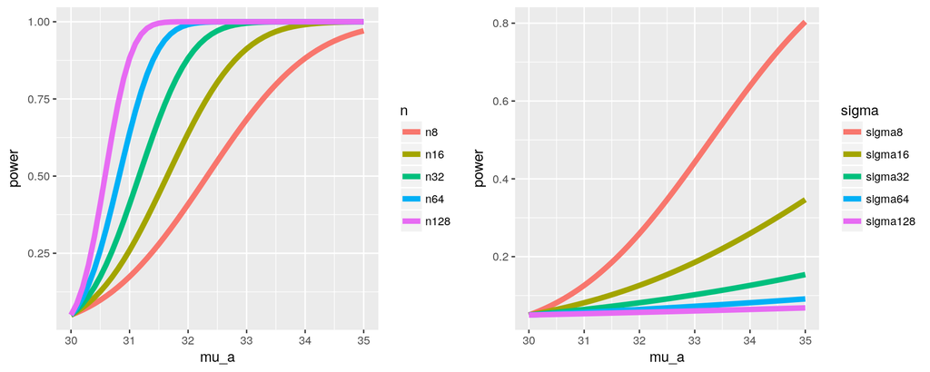

```r
library(ggplot2)
library(reshape2)

mu0 = 30; sigma = 4; n = 16
alpha = 0.05
z = qnorm(1 - alpha)

# varying n
nseq = c(8, 16, 32, 64, 128)
mu_a = seq(30, 35, by = 0.1)
power = sapply(nseq, function(n)
    pnorm(mu0 + z * sigma / sqrt(n), mean = mu_a, sd = sigma / sqrt(n),
        lower.tail = FALSE)
    )
colnames(power) <- paste("n", nseq, sep = "")
d <- data.frame(mu_a, power)
d2 <- melt(d, id.vars = "mu_a")
names(d2) <- c("mu_a", "n", "power")
g1 <- ggplot(d2, aes(x = mu_a, y = power, col = n)) + geom_line(size = 2)

# varying sigma
sigseq = c(8, 16, 32, 64, 128)
power = sapply(sigseq, function(sigma)
    pnorm(mu0 + z * sigma / sqrt(n), mean = mu_a, sd = sigma / sqrt(n),
        lower.tail = FALSE)
)
colnames(power) <- paste("sigma", sigseq, sep = "")
d <- data.frame(mu_a, power)
d2 <- melt(d, id.vars = "mu_a")
names(d2) <- c("mu_a", "sigma", "power")
g2 <- ggplot(d2, aes(x = mu_a, y = power, col = sigma)) + geom_line(size = 2)

# plotting side-by-side
grid.arrange(g1, g2, ncol = 2)
```

- **Graphical Depiction of Power**

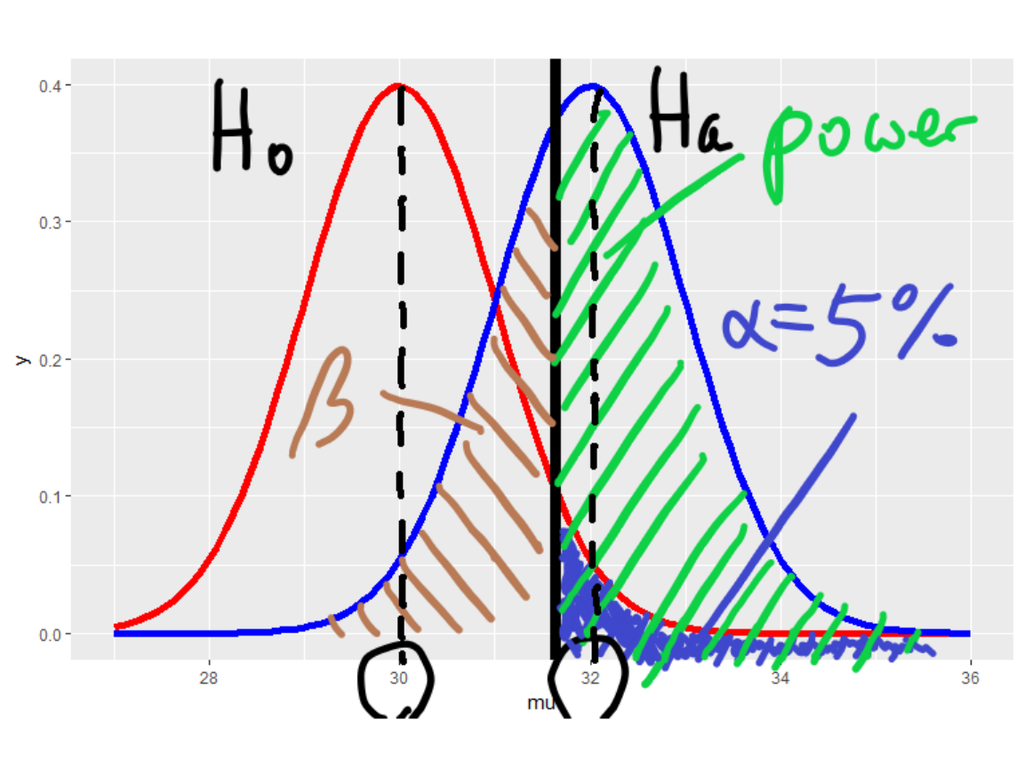

```r
library(manipulate)
mu0 = 30
myplot <- function(sigma, mua, n, alpha){
    g = ggplot(data.frame(mu = c(27, 36)), aes(x = mu))
    # distribution of sample mean under H_0
    g = g + stat_function(fun=dnorm, geom = "line",
                          args = list(mean = mu0, sd = sigma / sqrt(n)),
                          size = 2, col = "red")
    # distribution of sample mean under H_a
    g = g + stat_function(fun=dnorm, geom = "line",
                          args = list(mean = mua, sd = sigma / sqrt(n)),
                          size = 2, col = "blue")
    xitc = mu0 + qnorm(1 - alpha) * sigma / sqrt(n)
    g = g + geom_vline(xintercept=xitc, size = 3)
    g
}
manipulate(
    myplot(sigma, mua, n, alpha),
    sigma = slider(1, 10, step = 1, initial = 4),
    mua = slider(30, 35, step = 1, initial = 32),
    n = slider(1, 50, step = 1, initial = 16),
    alpha = slider(0.01, 0.1, step = 0.01, initial = 0.05)
    )
```

- **Solving for Power**
  - When testing $H_a : \mu > \mu_0$ (or $<$ or $\neq$)
    $$Power = 1 - \beta = P\left(\bar X > \mu_0 + Z_{1-\alpha} \frac{\sigma}{\sqrt{n}} ; \mu = \mu_a \right)$$
    where $\bar X \sim N(\mu_a, \sigma^2 / n)$
  - Unknowns = $\mu_a$, $\sigma$, $n$, $\beta$
  - Knowns = $\mu_0$, $\alpha$ (specified by the test designer)
  - Specify any 3 of the unknowns and you can solve for the remainder; most common are two cases
    1. Given power desired, mean to detect, variance that we can tolerate, find the $n$ to produce desired power (designing experiment/trial)
    2. Given the size $n$ of the sample, find the power that is achievable (finding the utility of experiment)
  - **Note**: for $H_a: \mu \neq \mu_0$, calculated one-sided power using $z_{1-\alpha / 2}$; however, the power calculation here excludes the probability of getting a large test statistic in the opposite direction of the truth, but this is only applicable when $\mu_a$ and $\mu_0$ are close together
- **Power Behavior**
  - Power increases as $\alpha$ becomes larger
  - Power of one-sided test $>$ power of associated two-sided test
  - Power increases as $\mu_a$ gets further away from $\mu_0$
  - Power increases as $n$ increases (sample mean has less variability)
  - Power increases as $\sigma$ decreases (again less variability)
  - Power usually depends only $\frac{\sqrt{n}(\mu_a - \mu_0)}{\sigma}$, and not $\mu_a$, $\sigma$, and $n$, individually
    - **effect size** = the difference in the means in standard deviation units = $\frac{\mu_a - \mu_0}{\sigma}$ $\rightarrow$ unit free, can be interpretted across settings
- **T-test Power**
  - for Gossett’s T test,
    $$Power = P\left(\frac{\bar X - \mu_0}{S/\sqrt{n}} > t_{1-\alpha, n-1} ; \mu = \mu_a \right)$$
    - $\frac{\bar X - \mu_0}{S/\sqrt{n}}$ does not follow a t distribution if the true mean is $\mu_a$ and NOT $\mu_0$ $\rightarrow$ follows a non-central t distribution instead
  - `power.t.test` = evaluates the non-central t distribution and solves for a parameter given all others are specified
    - `power.t.test(n = 16, delta = 0.5, sd = 1, type = "one.sample", alt = "one.sided")$power` = calculates power with inputs of n, difference in means, and standard deviation
      - `delta` = argument for **difference in means**
      - **Note**: since effect size = `delta/sd`, as `n`, `type`, and `alt` are held constant, any distribution with the same effect size will have the same power
    - `power.t.test(power = 0.8, delta = 0.5, sd = 1, type = "one.sample", alt = "one.sided")$n` = calculates size n with inputs of power, difference in means, and standard deviation
      - **Note**: n should always be rounded up (ceiling)
  - *Example*:
    - specify 3 unknowns out of 4 to calculate the remaining unknown (Unknowns = $\mu_a$, $\sigma$, $n$, $\beta$)
    - Knowns = $\mu_0$, $\alpha$
    - `delta` = $\mu_a - \mu_0$

  `r power.t.test(n = 16, delta = 2, sd=4, type = "one.sample", alt = "one.sided")$power`

  `## [1] 0.6040329`

  `r power.t.test(power = .8, delta = 2, sd=4, type = "one.sample", alt = "one.sided")$n`

  `## [1] 26.13751`

# 15 Multiple Testing

- **Intro**: We talked about hypothesis testing early in the course and I mentioned that we when you perform more than one hypothesis test you have to do some sort of correction to make sure that you’re not fooling yourself.
- Given that data is valuable and we’d like to get the most out of it, we might use it to test several hypotheses. If we have an alpha level of .05 and we test 20 hypotheses, then on average, we expect one error, just by chance.
- Another potential problem is that hypothesis testing in significant analysis are commonly overused techniques: what people will often do is calcula, calculate multiple P values when analysing the same data set, and they will only report the smallest P value or report all of the P values but claim all P values less than .05 are significant which leads to some problems
- correct for multiple testing to avoid false positives or false discoveries
- Two key components
  1. definition of an **error measure** that you would like to control
  2. definition of a **correction** or a statistical method that’s used to control that error measure
- multiple testing is needed because of the increase in ubiquitous data collection technology and analysis
  - DNA sequencing machines
  - imaging patients in clinical studies
  - electronic medical records
  - individualized movement data (fitbit)

## 15.1 Type of Errors

- Suppose you are testing a hypothesis that a parameter $\beta$ equals zero versus the alternative that it does not equal zero. These are the possible outcomes.

| Claim\Actual | $\beta=0$ | $\beta\neq0$ | Total |
| --- | --- | --- | --- |
| Claim $H_0: \beta=0$ (non-significant; negative) | $U$ | $T$ | $m-R$ |
| Claim $H_a: \beta\neq 0$ (significant; positive) | $V$ | $S$ | $R$ (discoveries) |
| Total | $m_0$ | $m-m_0$ | $m$ |

- **$V$** = Type I Error / **false positives**, number of cases falsely declared significant (reject true $H_0$)
- **$T$** = Type II Error / **false negatives**, number of cases falsely declared non-significant (accept false $H_0$)
- **$U$** = true negatives
- **$S$** = true positives
- **$m_0$** = number of true null hypotheses, or cases where $H_0$ = actually true (unknown)
- **$m - m_0$** = number of true alternative hypotheses, or cases where $H_a$ = actually true (unknown)
- **$R$** = number of null hypotheses rejected, or cases where $H_a$ = concluded to be true (measurable)
- **$m - R$** = number of null hypotheses that failed to be rejected, or cases where $H_0$ = concluded to be true (measurable)
- **m** = total number of hypothesis tests performed
- Known = $m$ and $R$; $V$ and other values are random variables (ie. unknown until we do an experiment)
- discoveries = something different from the status quo (that is $H_0$)

## 15.2 Error Rates

- *false positive rate* = rate at which false results are called significant $E[\frac{V}{m_0}]$ $\rightarrow$ average fraction of times that $H_a$ is claimed to be true when $H_0$ is actually true
  - **Note**: mathematically equal to type I error rate $\rightarrow$ false positive rate is associated with a post-prior result, which is the expected number of false positives divided by the total number of hypotheses under the real combination of true and non-true null hypotheses (disregarding the “global null” hypothesis). Since the false positive rate is a parameter that is not controlled by the researcher, it cannot be identified with the significance level, which is what determines the type I error rate.
- *family wise error rate (FWER)* = probability of at least one false positive $Pr(V \ge 1)$
- *false discovery rate (FDR)* = rate at which claims of significance are false $E[\frac{V}{R}]$

## 15.3 Controlling error rates (adjusting $\alpha$)

- **Controlling false positive rate**
  - if P-values are correctly calculated, declaring all tests with $P<\alpha$ as significant (reject $H_0$) means that our false positive rate is at most alpha, on average. (we expect to get $\alpha \times m$ false positives on average)
  - with high values of $m$, false positive rate is very large as well
  - **Problem**: Suppose that you perform 10,000 tests and $\beta = 0$ for all of them.
    - Suppose that you call all $P < 0.05$ significant.
    - The expected number of false positives is: $10,000 \times 0.05 = 500$ false positives.
    - *How do we avoid so many false positives?* (Answer: $\rightarrow$ FWER, FDR)
- **Controlling family-wise error rate (FWER)**
  - The [Bonferroni correction](http://en.wikipedia.org/wiki/Bonferroni_correction) is the oldest multiple testing correction.
  - **Basic idea**:
    - Suppose you do $m$ tests
    - You want to control FWER at level $\alpha$ so that $Pr(V \geq 1) < \alpha$
      - can be done by simply reducing alpha dramatically
    - Calculate P-values normally
    - Set $\alpha_{fwer} = \alpha/m$
    - Call all $P$-values less than $\alpha_{fwer}$ significant
  - **Pros**: Easy to calculate, conservative
  - **Cons**: May be very conservative (too many results will fail)
- **Controlling false discovery rate (FDR)**
  - This is the most popular correction when performing *lots* of tests say in genomics, imaging, astronomy, or other signal-processing disciplines.
  - **Basic idea**:
    - Suppose you do $m$ tests
    - You want to control FDR, or $E\left[\frac{V}{R}\right]$ at level $\alpha$
    - Calculate P-values normally
    - Order the P-values from smallest to largest $P_{(1)},...,P_{(m)}$
    - Call any $P_{(i)} \leq \alpha \times \frac{i}{m}$ significant
  - This is the Benjamini-Hochberg method (BH):
    - A p-value is compared to a value that depends on its ranking
    - This is equivalent to finding the largest k such that $p_k <= (k \times alpha)/m$, (for a given $\alpha$) and then rejecting all the null hypotheses for $i=1,...,k$
  - **Pros**: Still pretty easy to calculate, less conservative (maybe much less)
  - **Cons**: Allows for more false positives, may behave strangely under dependence
- **Example**: adjusting threshold $\alpha$ level of rejecting the null h
  - 10 P-values with $\alpha = 0.20$

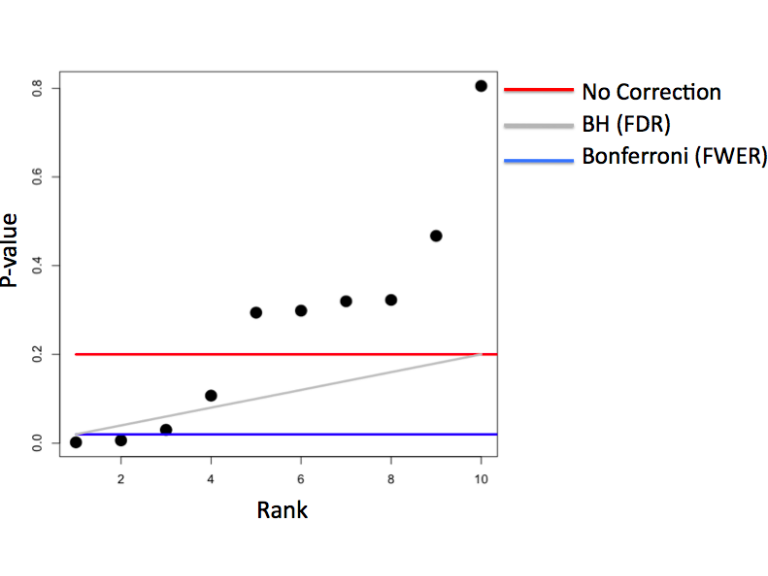

```r
set.seed(1010093)
pValues <- rep(NA,1000)
for(i in 1:1000){
    # no relationship between x & y
    y <- rnorm(20)
    x <- rnorm(20)
    # p-value stored in the 2nd row, 4th col of summary(lm())
    pValues[i] <- summary(lm(y ~ x))$coeff[2,4]
}

# Controls false positive rate
# no relationship between the 2 variables, but we still get ~5% false positives
sum(pValues < 0.05)
```

```
## [1] 51
```

```r
# Controls FWER
sum(p.adjust(pValues,method="bonferroni") < 0.05)
```

```
## [1] 0
```

```r
# Controls FDR
sum(p.adjust(pValues,method="BH") < 0.05)
```

```
## [1] 0
```

- **Case Study II**: 50% true positives

```r
set.seed(1010093)
pValues <- rep(NA,1000)
for(i in 1:1000){
  x <- rnorm(20)
  # First 500 beta=0, last 500 beta=2 (ie. relationship between x & y)
  if(i <= 500){y <- rnorm(20)}else{ y <- rnorm(20,mean=2*x)}
  # calculating p-values by using linear model; the [2, 4] coeff in result = pvalue
  pValues[i] <- summary(lm(y ~ x))$coeff[2,4]
}

# Controls false positive rate
# the case where there is actually no relationship between the two variables
# we get again about 5% of the time a false positive result (= 24/500)
trueStatus <- rep(c("zero","not zero"),each=500)
table(pValues < 0.05, trueStatus)
```

```
##        trueStatus
##         not zero zero
##   FALSE        0  476
##   TRUE       500   24
```

```r
# Controls FWER
# no false positives, however 23 of the truly significant results have been misidentified
table(p.adjust(pValues,method="bonferroni") < 0.05,trueStatus)
```

```
##        trueStatus
##         not zero zero
##   FALSE       23  500
##   TRUE       477    0
```

```r
# Controls FDR (Benjamin Hochberg)
table(p.adjust(pValues,method="BH") < 0.05,trueStatus)
```

```
##        trueStatus
##         not zero zero
##   FALSE        0  487
##   TRUE       500   13
```

- **P-values versus adjusted P-values**

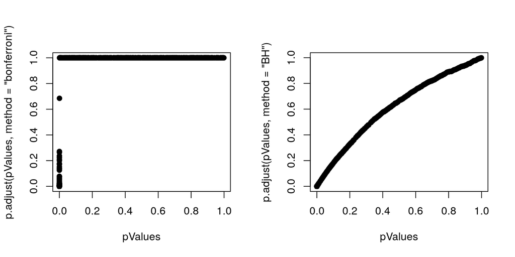

```r
par(mfrow=c(1,2))
plot(pValues,p.adjust(pValues,method="bonferroni"),pch=19)
plot(pValues,p.adjust(pValues,method="BH"),pch=19)
```

- **Notes**:
  - Multiple testing is an entire subfield
  - A basic Bonferroni/BH correction is usually enough
  - If there is **strong dependence** between tests there may be problems
    - Consider then method=“BY”
- **Further resources**:
  - [Multiple testing procedures with applications to genomics](http://www.amazon.com/Multiple-Procedures-Applications-Genomics-Statistics/dp/0387493166/ref=sr_1_2/102-3292576-129059?ie=UTF8&s=books&qid=1187394873&sr=1-2)
  - [Statistical significance for genome-wide studies](http://www.pnas.org/content/100/16/9440.full)
  - [Introduction to multiple testing](http://ies.ed.gov/ncee/pubs/20084018/app_b.asp)